# **Grupo 18: Estudio de factores de riesgo en pacientes Covid**

CC5205 Minería de Datos

Integrantes:

- Sebastián Cobaise (Sección 2)
- Bastián Garcés (Sección 1)
- Arturo Lazcano (Sección 2)
- Jonas Peñailillo (Sección 1)
- Eduardo Silva (Sección 2)

# **Introducción**

Las pandemias han estado presentes durante toda la historia de la humanidad, la primera de ellas, de la cual se tienen datos, corresponde a la Viruela, la cual fue descubierta en 1796 y dejó a más de 300 millones de fallecidos, convirtiendose así en la pandemia que registra la mayor cantidad de muertes. Actualmente el mundo se encuentra atravesando la más reciente de ellas, la corerspondiente al SARS-CoV-2 o más conocida popularmente como Covid-19. Esta enfermedad si bien no ha dejado la cantidad de victimas que la otra pandemia expuesta, ha interrumpido la vida diaría de los habitantes del planeta, generando así que muchas personas tuviesen que recluirse en sus hogares para evitar enfermarse. Es en línea con lo último mencionado que se deseaba averiguar con exactitud cuales eran los grupos de la población que tenían una mayor probabilidad de sobrevivir.

### Propuesta

Es debido a lo anterior que el grupo de trabajo correspondiente al curso CC5205 Mineria de Datos, se propuso como objetivo de proyecto el predecir que personas deberian fallecer por covid de acuerdo a una serie de características como la edad, el sexo, si está embarazada, si presenta alguna enfermedad como hipertensión, si esta intubado, entre otras condiciones. Para lograr lo anterior se hará uso del Dataset llamado "covid.csv" obtenido de la pagina web Kaggle.com. Este dataset publicado por el gobierno de mexico a finales del 2020, con el fin de analizar a fondo la situación del pais afectada por la pandemia, recopila información sobre diversas caracteristicas como las nombradas anteriormente, de más de 500.000 ciudadanos mexicanos a lo largo del año 2020. Además este dataset presenta otras caracteristicas relevantes como la fecha en la que el paciente presente sintomas de la enfermedad, fecha de muerte (si es que fallecio) y si tuvo contacto con otras personas contagiadas, tipo de atención medica que se le proporciono al paciente, entre otras.

Por lo tanto la primera pregunta que se buscara responder en este trabajo de mineria de datos sera: ¿Es posible predecir el fallecimiento de una persona en base a un conjunto de variables asociadas a diferentes enfermedades y caracteristicas de una persona?

Por otro lado, otra pregunta a plantear sera, ¿existen grupos de pacientes que se relacionen entre sí en base a sus condiciones? De esta forma se podra observar si hay pacientes que debido a sus enfermedades u otras caracteristicas se relacionen y puedan agruparse en distintas clases.

Finalmente se propone la pregunta ¿Existen patrones que relacionen las distintas condiciones entre los pacientes estudiados? donde mediante reglas de asociación se espera conseguir tendencias en los datos.

Durante el presente reporte se expone la exploración de datos realizada sobre el dataset, así como también algunas graficas que permiten evidenciar el comportamiento de los pacientes ante diversas características. Luego se expondra y aplicara la metodologia utilizada para resolver las preguntas propuestas anteriormente.

# **Exploración de Datos**

Para empezar a estudiar la base de datos, comenzamos importando librerías clásicas de Python para así leer el archivo .csv y visualizar la forma que tiene este.

```python
# Importar librerías a usar
import numpy as np
import matplotlib.pyplot as plt
import pandas as pd
import warnings
from matplotlib.ticker import FormatStrFormatter
import seaborn as sns
```

```python
# Cargamos el dataset a utilizar (Celda válida para Google Colaboratory)
!gdown --id 1O-MCONdfx94dbfrkyCSOa3ZVFrx7ip_Q
```

```python
# Leer y crear el dataframe
df= pd.read_csv("covid.csv")
```

```python
df
```

|  | id | sex | patient_type | entry_date | date_symptoms | date_died | intubed | pneumonia | age | pregnancy | ... | inmsupr | hypertension | other_disease | cardiovascular | obesity | renal_chronic | tobacco | contact_other_covid | covid_res | icu |
| --- | --- | --- | --- | --- | --- | --- | --- | --- | --- | --- | --- | --- | --- | --- | --- | --- | --- | --- | --- | --- | --- |
| 0 | 16169f | 2 | 1 | 04-05-2020 | 02-05-2020 | 9999-99-99 | 97 | 2 | 27 | 97 | ... | 2 | 2 | 2 | 2 | 2 | 2 | 2 | 2 | 1 | 97 |
| 1 | 1009bf | 2 | 1 | 19-03-2020 | 17-03-2020 | 9999-99-99 | 97 | 2 | 24 | 97 | ... | 2 | 2 | 2 | 2 | 2 | 2 | 2 | 99 | 1 | 97 |
| 2 | 167386 | 1 | 2 | 06-04-2020 | 01-04-2020 | 9999-99-99 | 2 | 2 | 54 | 2 | ... | 2 | 2 | 2 | 2 | 1 | 2 | 2 | 99 | 1 | 2 |
| 3 | 0b5948 | 2 | 2 | 17-04-2020 | 10-04-2020 | 9999-99-99 | 2 | 1 | 30 | 97 | ... | 2 | 2 | 2 | 2 | 2 | 2 | 2 | 99 | 1 | 2 |
| 4 | 0d01b5 | 1 | 2 | 13-04-2020 | 13-04-2020 | 22-04-2020 | 2 | 2 | 60 | 2 | ... | 2 | 1 | 2 | 1 | 2 | 2 | 2 | 99 | 1 | 2 |
| ... | ... | ... | ... | ... | ... | ... | ... | ... | ... | ... | ... | ... | ... | ... | ... | ... | ... | ... | ... | ... | ... |
| 566597 | 01ff60 | 2 | 1 | 13-05-2020 | 03-05-2020 | 9999-99-99 | 97 | 2 | 58 | 97 | ... | 2 | 2 | 2 | 2 | 2 | 2 | 2 | 2 | 3 | 97 |
| 566598 | 047cd1 | 1 | 1 | 07-04-2020 | 06-04-2020 | 9999-99-99 | 97 | 2 | 48 | 2 | ... | 2 | 2 | 2 | 2 | 2 | 2 | 2 | 2 | 3 | 97 |
| 566599 | 1beb81 | 1 | 2 | 14-05-2020 | 01-05-2020 | 9999-99-99 | 2 | 1 | 49 | 2 | ... | 2 | 2 | 2 | 2 | 1 | 2 | 2 | 99 | 3 | 2 |
| 566600 | 16fb02 | 1 | 1 | 31-05-2020 | 29-05-2020 | 9999-99-99 | 97 | 1 | 43 | 2 | ... | 2 | 2 | 2 | 2 | 2 | 2 | 2 | 2 | 3 | 97 |
| 566601 | 0021c9 | 2 | 1 | 16-05-2020 | 16-05-2020 | 9999-99-99 | 97 | 1 | 65 | 97 | ... | 2 | 1 | 2 | 2 | 1 | 2 | 2 | 2 | 3 | 97 |

566602 rows × 23 columns

En el siguiente código se crea la función "filtrar", la cual permitira modificar valores irrelevantes en alguna columna.

```python
# Función para reemplazar valores 97,98,99 a 2
def filtrar(a):
  if a==2 or a==97 or a==98 or a==99:
    return 2
  else:
    return 1
```

A continuación se crea y añade al dataset la columna "died", que basandose en la información de la columna "date_died", entrega un binario que indica si el paciente fallecio o no por la enfermedad Covid-19. Esta correspondera a la clase que se propone predecir en la primera pregunta propuesta en este reporte.

```python
# Crear columna died
df["died"] = np.where(df["date_died"] == "9999-99-99", 0, 1)
# Remover valores 98 y 99 de los datos
for c in [df.pregnancy,df.intubed,df.pneumonia,df.diabetes,df.copd,df.asthma,df.inmsupr,df.hypertension,df.other_disease,df.cardiovascular,df.obesity,df.renal_chronic,df.tobacco,df.icu,df.contact_other_covid, df.covid_res]:
  df = df[c != 98]
  df = df[c != 99]

# Cambiar 97 por 2
for c in ['pregnancy','intubed','pneumonia','diabetes','copd','asthma','inmsupr','hypertension','other_disease','cardiovascular','obesity','renal_chronic','tobacco','icu']:
  df[c] = df[c].apply(filtrar)
```

```python
df
```

|  | id | sex | patient_type | entry_date | date_symptoms | date_died | intubed | pneumonia | age | pregnancy | ... | hypertension | other_disease | cardiovascular | obesity | renal_chronic | tobacco | contact_other_covid | covid_res | icu | died |
| --- | --- | --- | --- | --- | --- | --- | --- | --- | --- | --- | --- | --- | --- | --- | --- | --- | --- | --- | --- | --- | --- |
| 0 | 16169f | 2 | 1 | 04-05-2020 | 02-05-2020 | 9999-99-99 | 2 | 2 | 27 | 2 | ... | 2 | 2 | 2 | 2 | 2 | 2 | 2 | 1 | 2 | 0 |
| 7 | 0ce1f5 | 1 | 1 | 21-05-2020 | 18-05-2020 | 9999-99-99 | 2 | 2 | 56 | 2 | ... | 1 | 2 | 2 | 2 | 1 | 1 | 1 | 1 | 2 | 0 |
| 13 | 11c741 | 1 | 1 | 25-05-2020 | 23-05-2020 | 9999-99-99 | 2 | 2 | 34 | 2 | ... | 2 | 2 | 2 | 2 | 2 | 2 | 1 | 1 | 2 | 0 |
| 15 | 194bf2 | 1 | 1 | 20-06-2020 | 16-06-2020 | 9999-99-99 | 2 | 2 | 34 | 2 | ... | 2 | 2 | 2 | 2 | 2 | 1 | 2 | 1 | 2 | 0 |
| 16 | 158eef | 1 | 1 | 24-06-2020 | 15-06-2020 | 9999-99-99 | 2 | 2 | 49 | 2 | ... | 2 | 2 | 2 | 2 | 2 | 2 | 1 | 1 | 2 | 0 |
| ... | ... | ... | ... | ... | ... | ... | ... | ... | ... | ... | ... | ... | ... | ... | ... | ... | ... | ... | ... | ... | ... |
| 566596 | 1.44E+80 | 2 | 1 | 05-05-2020 | 02-05-2020 | 9999-99-99 | 2 | 2 | 46 | 2 | ... | 2 | 2 | 2 | 2 | 2 | 2 | 1 | 3 | 2 | 0 |
| 566597 | 01ff60 | 2 | 1 | 13-05-2020 | 03-05-2020 | 9999-99-99 | 2 | 2 | 58 | 2 | ... | 2 | 2 | 2 | 2 | 2 | 2 | 2 | 3 | 2 | 0 |
| 566598 | 047cd1 | 1 | 1 | 07-04-2020 | 06-04-2020 | 9999-99-99 | 2 | 2 | 48 | 2 | ... | 2 | 2 | 2 | 2 | 2 | 2 | 2 | 3 | 2 | 0 |
| 566600 | 16fb02 | 1 | 1 | 31-05-2020 | 29-05-2020 | 9999-99-99 | 2 | 1 | 43 | 2 | ... | 2 | 2 | 2 | 2 | 2 | 2 | 2 | 3 | 2 | 0 |
| 566601 | 0021c9 | 2 | 1 | 16-05-2020 | 16-05-2020 | 9999-99-99 | 2 | 1 | 65 | 2 | ... | 1 | 2 | 2 | 1 | 2 | 2 | 2 | 3 | 2 | 0 |

387575 rows × 24 columns

```python
# Explicación de columnas
print('Las columnas del dataframe son: \n',np.array(df.columns))
```

```
Las columnas del dataframe son:
 ['id' 'sex' 'patient_type' 'entry_date' 'date_symptoms' 'date_died'
 'intubed' 'pneumonia' 'age' 'pregnancy' 'diabetes' 'copd' 'asthma'
 'inmsupr' 'hypertension' 'other_disease' 'cardiovascular' 'obesity'
 'renal_chronic' 'tobacco' 'contact_other_covid' 'covid_res' 'icu' 'died']
```

En el siguiente código se crea la función "cantidad", la cual permitira calcular la cantidad de los distintos tipos de valores que hay en una columna.

```python
# Función para calcular la cantidad de valores 1, 2 , 97, 98, 99 sobre una columna del df
# Input: L --> columna de dataframe
# Output: a --> dict con las llaves 1,2,97,98,99 y los valores correspondientes a la cantidad que aparecen
def cantidad(L):
  numeros=list(set(L))
  a={}
  for n in numeros:
    a[n]=0
  for i in L:
    a[i]+=1
  return a
```

En la siguiente celda se extrae información básica de la base de datos, tal como si existen valores nulos para posible eliminación, cantidad de hombres y mujeres, promedio de edad, tipos de pacientes, cantidad de intubados y de diagnosticados con neumonía.

```python
# Revisar si hay valores NaN
if df.isnull().values.any():
  print('¿Hay valores NaN?: Si')
else:
  print('¿Hay valores NaN?: No')
# Conteo de pacientes vivos y muertos
print('Hay',cantidad(df['died'])[1],'muertos y',cantidad(df['died'])[0],'vivos')
# Conteo de pacientes hombres y mujeres
print('Hay',cantidad(df['sex'])[2],'hombres y',cantidad(df['sex'])[1],'mujeres')
# Promedio de edad
print('Promedio de edad: ',int(np.mean(df['age'])*100)/100)
# Cantidad de pacientes hospitalizados o no hospitalizados
print('Hay',cantidad(df['patient_type'])[1],'pacientes ambulatorios y',cantidad(df['patient_type'])[2],'hospitalizados')
# Cantidad de pacientes intubados
print('Hay',cantidad(df['intubed'])[1],'pacientes que requirieron intubación,',cantidad(df['intubed'])[2],'que no')
# Cantidad de pacientes diagnosticados por neumonía
print('Hay',cantidad(df['pneumonia'])[1],'pacientes diagnosticados con neumonía y',cantidad(df['pneumonia'])[2],'no diagnosticados con neumonía')
# Cantidad de pacientes que entraron a la uci
print('Hay',cantidad(df['icu'])[1],'que requirieron uci,',cantidad(df['icu'])[2],'que no requirieron uci')
```

```
¿Hay valores NaN?: No
Hay 13657 muertos y 373918 vivos
Hay 197105 hombres y 190470 mujeres
Promedio de edad:  41.48
Hay 328924 pacientes ambulatorios y 58651 hospitalizados
Hay 7622 pacientes que requirieron intubación, 379953 que no
Hay 49374 pacientes diagnosticados con neumonía y 338201 no diagnosticados con neumonía
Hay 7567 que requirieron uci, 380008 que no requirieron uci
```

En la siguiente celda, se creara y presentara la matriz de correlación de Pearson (correlación estandar).

```python
# Matriz de correlación
MC=df.corr()
MC
```

|  | sex | patient_type | intubed | pneumonia | age | pregnancy | diabetes | copd | asthma | inmsupr | hypertension | other_disease | cardiovascular | obesity | renal_chronic | tobacco | contact_other_covid | covid_res | icu | died |
| --- | --- | --- | --- | --- | --- | --- | --- | --- | --- | --- | --- | --- | --- | --- | --- | --- | --- | --- | --- | --- |
| sex | 1.000000 | 0.081591 | -0.044038 | -0.079524 | 0.024740 | 0.085235 | -0.016046 | -0.001020 | 0.040858 | 0.010448 | -0.002999 | 0.016187 | -0.008601 | 0.015568 | -0.012186 | -0.100708 | 0.058444 | -0.042604 | -0.038076 | 0.059891 |
| patient_type | 0.081591 | 1.000000 | -0.335413 | -0.714337 | 0.248256 | -0.013162 | -0.232366 | -0.101518 | 0.011949 | -0.083395 | -0.189477 | -0.075633 | -0.090761 | -0.067494 | -0.114813 | -0.000124 | 0.236299 | -0.129379 | -0.334176 | 0.389209 |
| intubed | -0.044038 | -0.335413 | 1.000000 | 0.339421 | -0.104881 | -0.006507 | 0.102044 | 0.038541 | -0.009040 | 0.029094 | 0.083178 | 0.036817 | 0.042353 | 0.040156 | 0.054422 | 0.002533 | -0.089495 | 0.072494 | 0.517241 | -0.415171 |
| pneumonia | -0.079524 | -0.714337 | 0.339421 | 1.000000 | -0.254680 | -0.009507 | 0.221385 | 0.092878 | -0.011393 | 0.061690 | 0.181637 | 0.055829 | 0.080674 | 0.077982 | 0.101809 | 0.003703 | -0.192718 | 0.147822 | 0.301475 | -0.428411 |
| age | 0.024740 | 0.248256 | -0.104881 | -0.254680 | 1.000000 | 0.066127 | -0.315209 | -0.148724 | 0.022798 | -0.024198 | -0.375239 | -0.026333 | -0.128090 | -0.093711 | -0.087053 | -0.007872 | 0.109092 | -0.093963 | -0.083455 | 0.211924 |
| pregnancy | 0.085235 | -0.013162 | -0.006507 | -0.009507 | 0.066127 | 1.000000 | -0.021968 | -0.006526 | 0.001216 | -0.000912 | -0.026688 | 0.023961 | -0.008310 | -0.016663 | -0.006822 | -0.017577 | -0.030182 | -0.003238 | -0.000617 | 0.012313 |
| diabetes | -0.016046 | -0.232366 | 0.102044 | 0.221385 | -0.315209 | -0.021968 | 1.000000 | 0.089017 | 0.006231 | 0.044978 | 0.356576 | 0.031557 | 0.105982 | 0.119151 | 0.145869 | 0.012333 | -0.094140 | 0.072132 | 0.090874 | -0.163233 |
| copd | -0.001020 | -0.101518 | 0.038541 | 0.092878 | -0.148724 | -0.006526 | 0.089017 | 1.000000 | 0.039380 | 0.056008 | 0.107322 | 0.046269 | 0.104544 | 0.036133 | 0.066046 | 0.058433 | -0.048171 | 0.013440 | 0.034389 | -0.061413 |
| asthma | 0.040858 | 0.011949 | -0.009040 | -0.011393 | 0.022798 | 0.001216 | 0.006231 | 0.039380 | 1.000000 | 0.028191 | 0.018447 | 0.018978 | 0.022940 | 0.045721 | 0.009506 | 0.008740 | 0.009656 | -0.005585 | -0.005160 | 0.010799 |
| inmsupr | 0.010448 | -0.083395 | 0.029094 | 0.061690 | -0.024198 | -0.000912 | 0.044978 | 0.056008 | 0.028191 | 1.000000 | 0.039024 | 0.149366 | 0.064021 | 0.016665 | 0.095130 | 0.008580 | -0.036214 | -0.004873 | 0.039976 | -0.029961 |
| hypertension | -0.002999 | -0.189477 | 0.083178 | 0.181637 | -0.375239 | -0.026688 | 0.356576 | 0.107322 | 0.018447 | 0.039024 | 1.000000 | 0.048413 | 0.158614 | 0.165825 | 0.148057 | 0.006755 | -0.073612 | 0.056649 | 0.073593 | -0.138814 |
| other_disease | 0.016187 | -0.075633 | 0.036817 | 0.055829 | -0.026333 | 0.023961 | 0.031557 | 0.046269 | 0.018978 | 0.149366 | 0.048413 | 1.000000 | 0.088682 | 0.028498 | 0.067503 | 0.017254 | -0.027366 | -0.003570 | 0.043126 | -0.027704 |
| cardiovascular | -0.008601 | -0.090761 | 0.042353 | 0.080674 | -0.128090 | -0.008310 | 0.105982 | 0.104544 | 0.022940 | 0.064021 | 0.158614 | 0.088682 | 1.000000 | 0.057993 | 0.109136 | 0.026966 | -0.032571 | 0.009273 | 0.043722 | -0.057374 |
| obesity | 0.015568 | -0.067494 | 0.040156 | 0.077982 | -0.093711 | -0.016663 | 0.119151 | 0.036133 | 0.045721 | 0.016665 | 0.165825 | 0.028498 | 0.057993 | 1.000000 | 0.021645 | 0.072921 | 0.002939 | 0.061614 | 0.035207 | -0.052918 |
| renal_chronic | -0.012186 | -0.114813 | 0.054422 | 0.101809 | -0.087053 | -0.006822 | 0.145869 | 0.066046 | 0.009506 | 0.095130 | 0.148057 | 0.067503 | 0.109136 | 0.021645 | 1.000000 | 0.016217 | -0.050431 | 0.010752 | 0.044424 | -0.076160 |
| tobacco | -0.100708 | -0.000124 | 0.002533 | 0.003703 | -0.007872 | -0.017577 | 0.012333 | 0.058433 | 0.008740 | 0.008580 | 0.006755 | 0.017254 | 0.026966 | 0.072921 | 0.016217 | 1.000000 | 0.014390 | -0.010758 | -0.000596 | -0.001919 |
| contact_other_covid | 0.058444 | 0.236299 | -0.089495 | -0.192718 | 0.109092 | -0.030182 | -0.094140 | -0.048171 | 0.009656 | -0.036214 | -0.073612 | -0.027366 | -0.032571 | 0.002939 | -0.050431 | 0.014390 | 1.000000 | -0.032627 | -0.085215 | 0.125727 |
| covid_res | -0.042604 | -0.129379 | 0.072494 | 0.147822 | -0.093963 | -0.003238 | 0.072132 | 0.013440 | -0.005585 | -0.004873 | 0.056649 | -0.003570 | 0.009273 | 0.061614 | 0.010752 | -0.010758 | -0.032627 | 1.000000 | 0.051582 | -0.145591 |
| icu | -0.038076 | -0.334176 | 0.517241 | 0.301475 | -0.083455 | -0.000617 | 0.090874 | 0.034389 | -0.005160 | 0.039976 | 0.073593 | 0.043126 | 0.043722 | 0.035207 | 0.044424 | -0.000596 | -0.085215 | 0.051582 | 1.000000 | -0.262500 |
| died | 0.059891 | 0.389209 | -0.415171 | -0.428411 | 0.211924 | 0.012313 | -0.163233 | -0.061413 | 0.010799 | -0.029961 | -0.138814 | -0.027704 | -0.057374 | -0.052918 | -0.076160 | -0.001919 | 0.125727 | -0.145591 | -0.262500 | 1.000000 |

En el siguiente código se crea un mapa de calor de la matriz de confusión anterior, para observar visualmente cuales son las caracteristicas más relacionadas con la columna "died". Es decir, se busca observar que condiciones de los pacientes influyen mayormente si viven o fallecen por covid

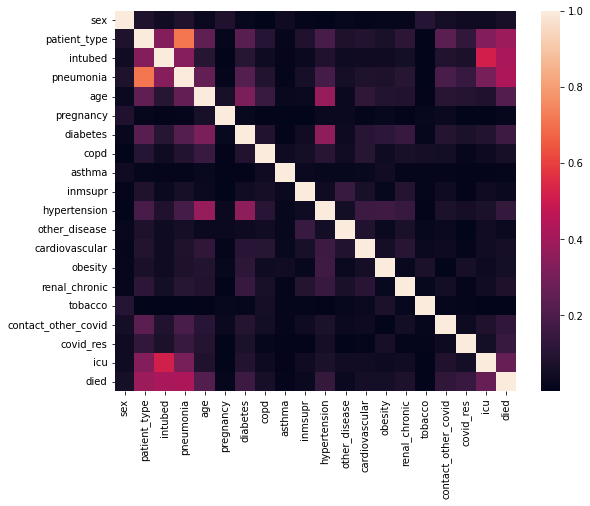

```
Valores de correlación de todas las caracteristicas con la columna died:
```

```
sex                    0.059891
patient_type           0.389209
intubed                0.415171
pneumonia              0.428411
age                    0.211924
pregnancy              0.012313
diabetes               0.163233
copd                   0.061413
asthma                 0.010799
inmsupr                0.029961
hypertension           0.138814
other_disease          0.027704
cardiovascular         0.057374
obesity                0.052918
renal_chronic          0.076160
tobacco                0.001919
contact_other_covid    0.125727
covid_res              0.145591
icu                    0.262500
died                   1.000000
Name: died, dtype: float64
```

```python
#Mapa para observar visualmente las variables más relacionadas con data_death

Matriz_valorAbsoluto=abs(MC)
plt.figure(figsize=(9, 7))
sns.heatmap(Matriz_valorAbsoluto, annot=False)
plt.show()

print(" ")
print("Valores de correlación de todas las caracteristicas con la columna died:")
print(" ")
Matriz_valorAbsoluto["died"]
```

En el siguiente código se guardaran los valores de correlación de todas las caracteristicas con la columna "died". Luego se ordenaran de forma creciente y se buscaran las 7 caracteristicas con mayor correlación.

```python
#caracteristicas relacionadas con date_died ordenadas de manera creciente segun su correlación:
dic= dict(zip(MC.columns, Matriz_valorAbsoluto["died"] ))
valores_ordenados=sorted(dic.items(), key=lambda x: x[1])
valores_ordenados[12:19]
```

```
[('covid_res', 0.1455910921461116),
 ('diabetes', 0.16323341503154715),
 ('age', 0.21192432986341225),
 ('icu', 0.2625001113330104),
 ('patient_type', 0.38920863220966645),
 ('intubed', 0.41517090822781055),
 ('pneumonia', 0.42841058057962866)]
```

### Graficos de barra

A continuación se realizaran diversos graficos de barra de las caracteristicas más correlacionadas con la columna "died". De esta forma, se podran visualizar cuantos muertos y vivos hay según cada una de las condiciones definidas anteriormente.

```
patient_type  died
1             0       327301
              1         1623
2             0        46617
              1        12034
dtype: int64
```

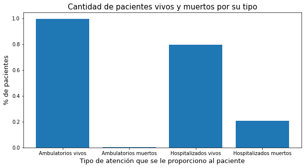

```python
# Gráfico de barras de variables más significativas dada su correlación
# --- Tipo de Paciente ---
fig = plt.figure(figsize = (10,5))
y=df.groupby(["patient_type", "died"]).size()
x=['Ambulatorios vivos','Ambulatorios muertos','Hospitalizados vivos' ,'Hospitalizados muertos']
yy=list(y)
print(y)
#normalizado
a=(yy[0]+yy[1])
b=(yy[2]+yy[3])
yy[0]=yy[0]/a
yy[2]=yy[2]/b
yy[1]=yy[1]/a
yy[3]=yy[3]/b

plt.bar(x,yy)
plt.title('Cantidad de pacientes vivos y muertos por su tipo', fontsize=15)
plt.xlabel('Tipo de atención que se le proporciono al paciente', fontsize=13)
plt.ylabel('% de pacientes', fontsize=13)
plt.show()
```

```
pneumonia  died
1          0        37427
           1        11947
2          0       336491
           1         1710
dtype: int64
```

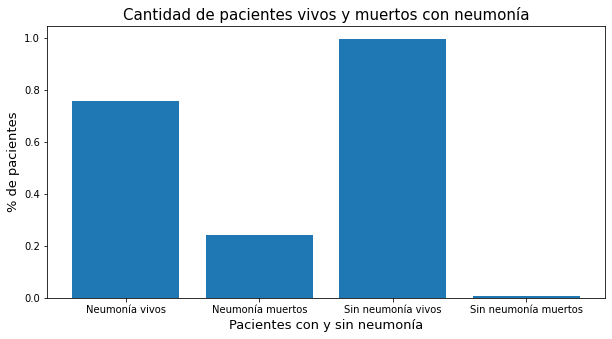

```python
# Gráfico de barras de variables más significativas dada su correlación
# --- Neumonía ---
fig = plt.figure(figsize = (10,5))
y=df.groupby(["pneumonia", "died"]).size()
x=['Neumonía vivos','Neumonía muertos','Sin neumonía vivos' ,'Sin neumonía muertos']
yy=list(y)
print(y)
#normalizado
a=(yy[0]+yy[1])
b=(yy[2]+yy[3])
yy[0]=yy[0]/a
yy[2]=yy[2]/b
yy[1]=yy[1]/a
yy[3]=yy[3]/b

plt.bar(x,yy)
plt.title('Cantidad de pacientes vivos y muertos con neumonía', fontsize=15)
plt.xlabel('Pacientes con y sin neumonía', fontsize=13)
plt.ylabel('% de pacientes', fontsize=13)
plt.show()
```

```
intubed  died
1        0         3234
         1         4388
2        0       370684
         1         9269
dtype: int64
```

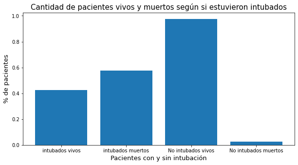

```python
# Gráfico de barras de variables más significativas dada su correlación
# --- intubados ---
fig = plt.figure(figsize = (10,5))
y=df.groupby(["intubed", "died"]).size()
x=['intubados vivos','intubados muertos','No intubados vivos' ,'No intubados muertos']
yy=list(y)
print(y)
#normalizado
a=(yy[0]+yy[1])
b=(yy[2]+yy[3])
yy[0]=yy[0]/a
yy[2]=yy[2]/b
yy[1]=yy[1]/a
yy[3]=yy[3]/b

plt.bar(x,yy)
plt.title('Cantidad de pacientes vivos y muertos según si estuvieron intubados', fontsize=15)
plt.xlabel('Pacientes con y sin intubación', fontsize=13)
plt.ylabel('% de pacientes', fontsize=13)
plt.show()
```

```
diabetes  died
1         0        36378
          1         5065
2         0       337540
          1         8592
dtype: int64
```

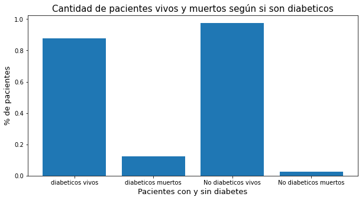

```python
# Gráfico de barras de variables más significativas dada su correlación
# --- diabetes ---
fig = plt.figure(figsize = (10,5))
y=df.groupby(["diabetes", "died"]).size()
x=['diabeticos vivos','diabeticos muertos','No diabeticos vivos' ,'No diabeticos muertos']
yy=list(y)
print(y)
#normalizado
a=(yy[0]+yy[1])
b=(yy[2]+yy[3])
yy[0]=yy[0]/a
yy[2]=yy[2]/b
yy[1]=yy[1]/a
yy[3]=yy[3]/b

plt.bar(x,yy)
plt.title('Cantidad de pacientes vivos y muertos según si son diabeticos', fontsize=15)
plt.xlabel('Pacientes con y sin diabetes', fontsize=13)
plt.ylabel('% de pacientes', fontsize=13)
plt.show()
```

```
hypertension  died
1             0        48573
              1         5332
2             0       325345
              1         8325
dtype: int64
```

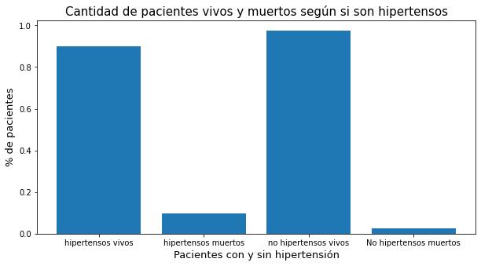

```python
# Gráfico de barras de variables más significativas dada su correlación
# --- hipertensión ---
fig = plt.figure(figsize = (10,5))
y=df.groupby(["hypertension", "died"]).size()
x=['hipertensos vivos','hipertensos muertos','no hipertensos vivos' ,'No hipertensos muertos']
yy=list(y)
print(y)
#normalizado
a=(yy[0]+yy[1])
b=(yy[2]+yy[3])
yy[0]=yy[0]/a
yy[2]=yy[2]/b
yy[1]=yy[1]/a
yy[3]=yy[3]/b

plt.bar(x,yy)
plt.title('Cantidad de pacientes vivos y muertos según si son hipertensos', fontsize=15)
plt.xlabel('Pacientes con y sin hipertensión', fontsize=13)
plt.ylabel('% de pacientes', fontsize=13)
plt.show()
```

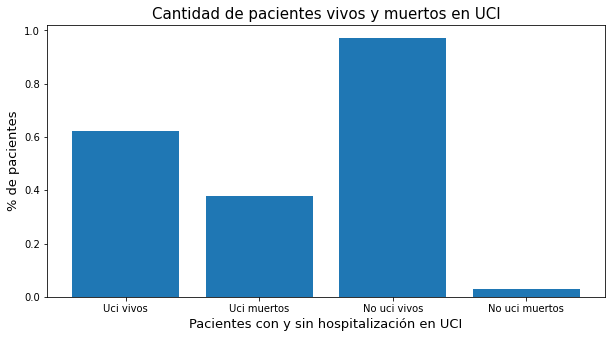

```python
#NORMALIZADO
# Gráfico de barras de variables más significativas dada su correlación
# --- UCI ---
fig = plt.figure(figsize = (10,5))
y=df.groupby(["icu", "died"]).size()
x=['Uci vivos','Uci muertos','No uci vivos' ,'No uci muertos']
yy=list(y)

#normalizado
a=(yy[0]+yy[1])
b=(yy[2]+yy[3])
yy[0]=yy[0]/a
yy[2]=yy[2]/b
yy[1]=yy[1]/a
yy[3]=yy[3]/b


plt.bar(x,yy)
plt.title('Cantidad de pacientes vivos y muertos en UCI', fontsize=15)
plt.xlabel('Pacientes con y sin hospitalización en UCI', fontsize=13)
plt.ylabel('% de pacientes', fontsize=13)
plt.show()
```

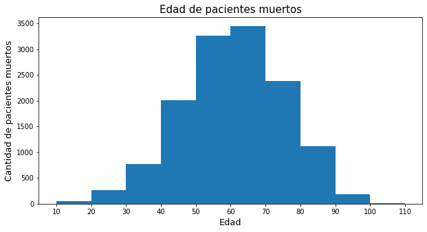

```python
# Histograma de variables más significativas dada su correlación
# --- Edad muertos ---
fig, ax = plt.subplots(figsize = (10,5))
counts, bins, patches = ax.hist(df[df.died == 1]['age'], bins=[10,20,30,40,50,60,70,80,90,100,110])
plt.title('Edad de pacientes muertos', fontsize=15)
plt.xlabel('Edad', fontsize=13)
plt.ylabel('Cantidad de pacientes muertos', fontsize=13)

ax.set_xticks(bins)
ax.xaxis.set_major_formatter(FormatStrFormatter('%0.f'))
```

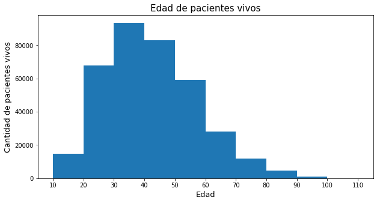

```python
# Histograma de variables más significativas dada su correlación
# --- Edad vivos ---
fig, ax = plt.subplots(figsize = (10,5))
counts, bins, patches = ax.hist(df[df.died == 0]['age'], bins=[10,20,30,40,50,60,70,80,90,100,110])
plt.title('Edad de pacientes vivos', fontsize=15)
plt.xlabel('Edad', fontsize=13)
plt.ylabel('Cantidad de pacientes vivos', fontsize=13)
ax.set_xticks(bins)
ax.xaxis.set_major_formatter(FormatStrFormatter('%0.f'))
```

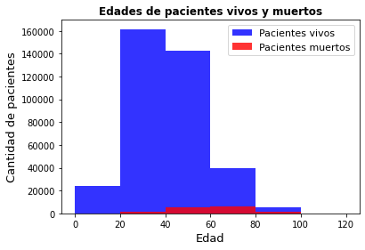

```python
#Grafico de edades junto.

df_vivos=df.loc[df["died"]==0]
df_muertos=df.loc[df["died"]==1]



bi=[0,20,40,60,80,100,120]

#a=sum(df_vivos['age'].value_counts(dropna=False))
#b=sum(df_muertos['age'].value_counts(dropna=False))


plt.hist(df_vivos["age"], bins=bi  ,color="blue" ,alpha=0.8, label="Pacientes vivos")
plt.hist(df_muertos["age"], bins=bi  ,color="red" ,alpha=0.8, label="Pacientes muertos")

plt.xlabel('Edad', fontsize=13)
plt.ylabel('Cantidad de pacientes', fontsize=13)

plt.legend(prop ={'size': 11})

plt.title('Edades de pacientes vivos y muertos',
          fontweight ="bold")
plt.show()
```

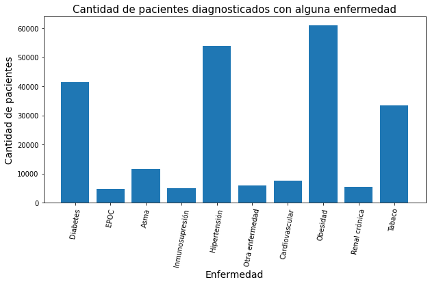

```python
# Función que grafica la cantidad de pacientes que posee alguna enfermedad de las que se presentan en la tabla
# Input: df (DataFrame)
# Output: None (realiza gráfico de barras)
def graficarEnfermedades(df):
  d=df['diabetes']
  e=df['copd']
  a=df['asthma']
  i=df['inmsupr']
  h=df['hypertension']
  o=df['other_disease']
  c=df['cardiovascular']
  ob=df['obesity']
  r=df['renal_chronic']
  t=df['tobacco']
  cantidades=[]
  ejex=['Diabetes','EPOC','Asma','Inmunosupresión','Hipertensión','Otra enfermedad','Cardiovascular','Obesidad','Renal crónica','Tabaco']
  for enf in [d,e,a,i,h,o,c,ob,r,t]:
    cantidades.append(cantidad(enf)[1])
  fig = plt.figure(figsize = (10,5))
  plt.bar(ejex,cantidades)
  y_pos=range(len(ejex))
  plt.xticks(y_pos, ejex, rotation=80)
  plt.title('Cantidad de pacientes diagnosticados con alguna enfermedad', fontsize=15)
  plt.xlabel('Enfermedad', fontsize=14)
  plt.ylabel('Cantidad de pacientes', fontsize=14)
graficarEnfermedades(df)
```

# **Metodologías**

Con el objetivo de responder las preguntas planteadas al inicio, se plantean metodologías que consideran tratamiento de datos e implementación de los algoritmos de mineria de datos vistos en el curso.

### Metodología 1

¿Es posible predecir el fallecimiento de una persona en base a un conjunto de variables asociadas a diferentes enfermedades y caracteristicas de una persona?

Para responder esta pregunta se plantea utilizar algoritmos de clasificación para predecir la columna "died" utilizando los atributos de la persona. Se plantea probar varios algoritmos (SVM, Random Forest y KNN), encontrar los parámetros óptimos de cada uno mediante GridSearch y analizar el desempeño de cada uno según métricas como recall y accuracy.

### Metodología 2

¿Existen grupos de pacientes que se relacionen entre sí en base a sus condiciones?

Con el fin de responder la segunda pregunta, se plantea el uso de un posible algoritmo de clustering para buscar grupos de pacientes fallecidos con el objetivo de obtener mayor información sobre estos.

Se propone utilizar el algoritmo de clustering k-means, dado que los centroides que da este método son interpretables, se debe determinar el número de clusters en base al método del codo y el score de silueta y se validarán los clusters.

También se visualizarán los datos con PCA, se descarta el t-SNE debido a que demora mucho en realizar este método.

### Metodología 3

¿Existen patrones que relacionen las distintas condiciones entre los pacientes estudiados?

El objetivo de esta pregunta es poder descubrir si existen caracteristicas que sean más probables de ocurrir en pacientes bajo ciertas condiciones. Para ello se analizaran las reglas de asociación del dataset.

Para obtener las reglas de asociación más importantes se utilizara el algoritmo apriori, y basandose en las metricas Support, Confidence y Lift se elegiran los patrones más probables de ocurrir.

# **Implementación de las metodologías**

### Metodología 1

Se implementa la metodología planteada previamente para contestar la primera pregunta del proyecto, si es posible predecir si un paciente sobrevive o no en base a sus características de edad, genero, si presenta alguna enfermedad como hipertensión, entre otras.

A continuación, se importan las librerías a usar, estas se enfocan en clasificadores tales como SVM, Random Forest y KNN. Junto a esto, también se hará uso de algoritmos típicos como train_test_split y GridSearch.

```python
#Librerias a usar
from datetime import datetime
from sklearn.model_selection import train_test_split,PredefinedSplit
import sklearn.preprocessing
from sklearn import svm
from sklearn.model_selection import GridSearchCV
from sklearn.metrics import confusion_matrix,accuracy_score
from sklearn.ensemble import RandomForestClassifier
from collections import Counter
from imblearn.under_sampling import RandomUnderSampler
from sklearn.decomposition import PCA
from sklearn.metrics import classification_report
from sklearn.neighbors import KNeighborsClassifier
```

Como un tratamiento inicial de los datos, se define una función capaz de retornar la diferencia entre 2 fechas usadas como parámetros.

```python
def date(string1, string2):
  '''
  Función encargada de entregar la diferencia en dias entre 2 fechas
  Inputs:
    string1: String con la fecha
    string2: String con la fecha

  Output:
    Diferencia en dias entre las dos fechas
  '''
  try:
    a = datetime.strptime(string1, '%d-%m-%Y') #Se pasa a formato date el string
    b = datetime.strptime(string2, '%d-%m-%Y') #Se pasa a formato date el string
    resta = int(str(a-b).split(' ')[0]) #Se obtienen la cantidad de dias
    if resta < 0: #Si la resta de fechas daba negativo en los dias se registra que la resta es -1 para identificarla
      resta = -1
    return resta
  except:
    return -1
```

Con el mismo objetivo sobre tratamiento de datos, se crea una nueva columna del DataFrame llamada "days" la cual tiene como dato la diferencia de días que existe entre la fecha en que el/la paciente presenta síntomas y la fecha en la que fallece. En caso de que no haya fallecido se registra con el valor -1.

```python
#Calculo de la diferencia de dias entre la fecha de muerte y la fecha en que presento sintomas
dias = []
for i in range(df.shape[0]):
  dias.append(date(df.date_died.iloc[i], df.date_symptoms.iloc[i]))
df['days'] = dias
```

```python
df
```

|  | id | sex | patient_type | entry_date | date_symptoms | date_died | intubed | pneumonia | age | pregnancy | ... | other_disease | cardiovascular | obesity | renal_chronic | tobacco | contact_other_covid | covid_res | icu | died | days |
| --- | --- | --- | --- | --- | --- | --- | --- | --- | --- | --- | --- | --- | --- | --- | --- | --- | --- | --- | --- | --- | --- |
| 0 | 16169f | 2 | 1 | 04-05-2020 | 02-05-2020 | 9999-99-99 | 2 | 2 | 27 | 2 | ... | 2 | 2 | 2 | 2 | 2 | 2 | 1 | 2 | 0 | -1 |
| 7 | 0ce1f5 | 1 | 1 | 21-05-2020 | 18-05-2020 | 9999-99-99 | 2 | 2 | 56 | 2 | ... | 2 | 2 | 2 | 1 | 1 | 1 | 1 | 2 | 0 | -1 |
| 13 | 11c741 | 1 | 1 | 25-05-2020 | 23-05-2020 | 9999-99-99 | 2 | 2 | 34 | 2 | ... | 2 | 2 | 2 | 2 | 2 | 1 | 1 | 2 | 0 | -1 |
| 15 | 194bf2 | 1 | 1 | 20-06-2020 | 16-06-2020 | 9999-99-99 | 2 | 2 | 34 | 2 | ... | 2 | 2 | 2 | 2 | 1 | 2 | 1 | 2 | 0 | -1 |
| 16 | 158eef | 1 | 1 | 24-06-2020 | 15-06-2020 | 9999-99-99 | 2 | 2 | 49 | 2 | ... | 2 | 2 | 2 | 2 | 2 | 1 | 1 | 2 | 0 | -1 |
| ... | ... | ... | ... | ... | ... | ... | ... | ... | ... | ... | ... | ... | ... | ... | ... | ... | ... | ... | ... | ... | ... |
| 566596 | 1.44E+80 | 2 | 1 | 05-05-2020 | 02-05-2020 | 9999-99-99 | 2 | 2 | 46 | 2 | ... | 2 | 2 | 2 | 2 | 2 | 1 | 3 | 2 | 0 | -1 |
| 566597 | 01ff60 | 2 | 1 | 13-05-2020 | 03-05-2020 | 9999-99-99 | 2 | 2 | 58 | 2 | ... | 2 | 2 | 2 | 2 | 2 | 2 | 3 | 2 | 0 | -1 |
| 566598 | 047cd1 | 1 | 1 | 07-04-2020 | 06-04-2020 | 9999-99-99 | 2 | 2 | 48 | 2 | ... | 2 | 2 | 2 | 2 | 2 | 2 | 3 | 2 | 0 | -1 |
| 566600 | 16fb02 | 1 | 1 | 31-05-2020 | 29-05-2020 | 9999-99-99 | 2 | 1 | 43 | 2 | ... | 2 | 2 | 2 | 2 | 2 | 2 | 3 | 2 | 0 | -1 |
| 566601 | 0021c9 | 2 | 1 | 16-05-2020 | 16-05-2020 | 9999-99-99 | 2 | 1 | 65 | 2 | ... | 2 | 2 | 1 | 2 | 2 | 2 | 3 | 2 | 0 | -1 |

387575 rows × 25 columns

A continuación, se definen las columnas que actúan como atributos o características, es decir, son los datos que se quieren usar para predecir si el paciente fallece o no. Para ello, se define una nueva columna llamada "died" la cual tiene datos binarios, o sea, 0 si está vivo y 1 si no.

```python
#Lista con los nombres de los atributos a usar
atributos = ['sex', 'patient_type', 'intubed', 'pneumonia', 'age', 'pregnancy', 'diabetes', 'copd',
       'asthma', 'inmsupr', 'hypertension', 'other_disease', 'cardiovascular',
       'obesity', 'renal_chronic', 'tobacco', 'contact_other_covid',
       'covid_res', 'icu']

#Lista con las clases
clases = ['died']
df2 = df[atributos+clases]
df2
```

|  | sex | patient_type | intubed | pneumonia | age | pregnancy | diabetes | copd | asthma | inmsupr | hypertension | other_disease | cardiovascular | obesity | renal_chronic | tobacco | contact_other_covid | covid_res | icu | died |
| --- | --- | --- | --- | --- | --- | --- | --- | --- | --- | --- | --- | --- | --- | --- | --- | --- | --- | --- | --- | --- |
| 0 | 2 | 1 | 2 | 2 | 27 | 2 | 2 | 2 | 2 | 2 | 2 | 2 | 2 | 2 | 2 | 2 | 2 | 1 | 2 | 0 |
| 7 | 1 | 1 | 2 | 2 | 56 | 2 | 2 | 2 | 2 | 2 | 1 | 2 | 2 | 2 | 1 | 1 | 1 | 1 | 2 | 0 |
| 13 | 1 | 1 | 2 | 2 | 34 | 2 | 2 | 2 | 2 | 2 | 2 | 2 | 2 | 2 | 2 | 2 | 1 | 1 | 2 | 0 |
| 15 | 1 | 1 | 2 | 2 | 34 | 2 | 2 | 2 | 2 | 2 | 2 | 2 | 2 | 2 | 2 | 1 | 2 | 1 | 2 | 0 |
| 16 | 1 | 1 | 2 | 2 | 49 | 2 | 1 | 2 | 2 | 2 | 2 | 2 | 2 | 2 | 2 | 2 | 1 | 1 | 2 | 0 |
| ... | ... | ... | ... | ... | ... | ... | ... | ... | ... | ... | ... | ... | ... | ... | ... | ... | ... | ... | ... | ... |
| 566596 | 2 | 1 | 2 | 2 | 46 | 2 | 1 | 2 | 2 | 2 | 2 | 2 | 2 | 2 | 2 | 2 | 1 | 3 | 2 | 0 |
| 566597 | 2 | 1 | 2 | 2 | 58 | 2 | 1 | 2 | 2 | 2 | 2 | 2 | 2 | 2 | 2 | 2 | 2 | 3 | 2 | 0 |
| 566598 | 1 | 1 | 2 | 2 | 48 | 2 | 2 | 2 | 2 | 2 | 2 | 2 | 2 | 2 | 2 | 2 | 2 | 3 | 2 | 0 |
| 566600 | 1 | 1 | 2 | 1 | 43 | 2 | 2 | 2 | 2 | 2 | 2 | 2 | 2 | 2 | 2 | 2 | 2 | 3 | 2 | 0 |
| 566601 | 2 | 1 | 2 | 1 | 65 | 2 | 1 | 2 | 2 | 2 | 1 | 2 | 2 | 1 | 2 | 2 | 2 | 3 | 2 | 0 |

387575 rows × 20 columns

Con el tratamiento de datos ya realizado, se sigue a la etapa de crear conjuntos de entrenamiento, prueba y validación. Utilizamos el conjunto de entrenamiento para entrenar los algoritmos de clasificación que estudiaremos. El conjunto de validación se utiliza cuando queremos calcular métricas al usar GridSearch, donde se desea encontrar los mejores hiper-parámetros de los algoritmos. Por último el conjunto de test se usa para presentar los resultados de cada algoritmo luego de que se encontraran los mejores hiper-parámetros.  
El conjunto de inicial prueba tiene un tamaño del 0.4 del total del conjunto, sin embargo, este se separa en el conjunto de prueba real junto con uno de validación, ambos del mismo tamaño. Es decir, los conjuntos finales son: Entrenamiento, validación y prueba, con una proporción de 0.6, 0.2, 0.2 respectivamente.

```python
#Creacion de conjuntos de entrenamiento, validacion y test
train, otro = train_test_split(df2, test_size=0.4, random_state=42, shuffle=True)
val, test = train_test_split(otro, test_size=0.5, random_state=42, shuffle=True)

train = train.reset_index(drop=True)
val = val.reset_index(drop=True)
test = test.reset_index(drop=True)
print('')
```

Dado el gran desbalance que tiene la base de datos con respecto a la columna "died", se sugiere trabajar con el método de undersampling al conjunto de datos que representa la gente viva, esto con el objetivo de sopesar el desbalanceo de los datos.  
La decisión de trabajar con undersampling y no con oversampling viene de que, dados los $\sim$500.000 datos, usar oversampling dejaría aproximadamente 1.000.000 de datos lo cual requiere de más tiempo y poder computacional para aplicar algoritmos.  
A continuación, se aplica undersampling sobre el conjunto de entrenamiento y de validación:

```python
rus = RandomUnderSampler(random_state=0)                                 #Define el metodo de undersampling
X_train, y_train = rus.fit_resample(train[atributos], train[clases[0]])  #Se aplica el metodo sobre el conjunto de entrenamiento
X_val, y_val = rus.fit_resample(val[atributos], val[clases[0]])          #Se aplica el conjunto sobre el conjunto de validacion

#Numero de ejemplos por clase para cada conjunto
print(sorted(Counter(y_train).items()))
print(' ')
print(sorted(Counter(y_val).items()))
```

```
[(0, 8214), (1, 8214)]

[(0, 2697), (1, 2697)]
```

Luego, como es habitual al trabajar con clasificadores, se prosigue a normalizar los datos de entrenamiento, validación y prueba usando StandardScaler de sklearn. Donde el StandardScaler es entrenado utilizando el conjunto de entrenamiento

```python
#Creamos el StandardScaler
scaler = sklearn.preprocessing.StandardScaler()

#Entrenamos el scaler en el conjunto de entrenamiento
scaler.fit(X_train)

#Aplicamos el scaler a los conjuntos
S_Entrena = scaler.transform(X_train)
S_Vali = scaler.transform(X_val)
S_Test = scaler.transform(test[atributos])

#Creamos los dataframe con los atributos normalizados
S_Entrena_class = pd.DataFrame(S_Entrena,columns=atributos).copy(deep=True)
S_Entrena_class[clases[0]] = y_train

s_Vali_class = pd.DataFrame(S_Vali,columns=atributos).copy(deep=True)
s_Vali_class[clases[0]] = y_val

y_test = test[clases[0]]
s_test_class = pd.DataFrame(S_Test,columns=atributos).copy(deep=True)
s_test_class[clases[0]] = y_test
```

Ahora se procede a concatenar los conjuntos de entrenamiento y validación, esto con el objetivo de usarlos en el algoritmo de GridSearch y así poder probar varios parámetros, seleccionando con los que obtengan los mejores resultados.

```python
#Concatenacion de conjuntos de entrenamiento y validacion para usarlo en el GridSearch
train_val = pd.concat([S_Entrena_class, s_Vali_class])

#Indicamos que elementos pertenecen a cada conjunto
grupo = []
for i in range(len(train_val[clases[0]])):
  if i > len(S_Entrena_class[clases[0]]):
    grupo.append(0)
  else:
    grupo.append(-1)
ps = PredefinedSplit(test_fold=grupo)
```

#### SVM

Como primer clasificador a implementar se eligió Support Vector Machine (SVM) el cual es un algoritmo típico, en el cual los hiperparámetros a probar son el cambio de kernel (rbf, lineal y polinomial), un parámetro de regularización C (0.1 y 1) y el grado del polinomio (2 y 3 en el kernel polinomial) junto con el parámetro gamma (0.001, 0.01 y 0.1).

```python
#Parametros a testear en el GridSearch
Parametros_d = [
    {"kernel": ["rbf"], "gamma": [0.001, 0.01, 0.1], "C": [0.1, 1]},
    {"kernel": ["linear"], "C": [0.1, 1]},
    {"kernel": ["poly"], 'C':[0.1, 1],'gamma':[0.001, 0.01, 0.1], 'degree':[3, 2]}
]

#Clasificador SVM
svc = svm.SVC(probability=False)

#Se buscan los parametros
clf = GridSearchCV(svc, Parametros_d,cv=ps)
clf.fit(train_val[atributos],train_val[clases[0]])
print('El mejor clasificador tienen como caracteristicas: ',clf.best_params_)
```

```
El mejor clasificador tienen como caracteristicas:  {'C': 1, 'gamma': 0.1, 'kernel': 'rbf'}
```

Con el clasificador ya entrenado y con los hiperparámetros ya seleccionados, se procede a realizar predicciones en el conjunto de validación, imprimiendo el "accuracy" y graficando la matriz de confusión para visualizar mejor los resultados.

```
El valor de accuracy del SVM sobre el conjunto de validacion es:  0.9016221507481471
```

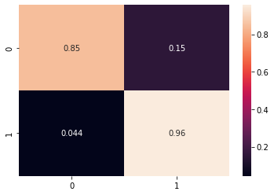

```python
#Se obtiene la prediccion sobre el conjunto de validacion
Val_SVM = clf.predict(s_Vali_class[atributos])
Real = list(y_val)
nor_matrix = confusion_matrix(Real, Val_SVM, normalize='true')
acur = accuracy_score(Real, Val_SVM)
print('El valor de accuracy del SVM sobre el conjunto de validacion es: ', acur)
sns.heatmap(nor_matrix,annot=True)
```

Luego, se realiza el mismo proceso comentado anteriormente pero esta vez usando el conjunto de prueba.

```
El valor de accuracy del SVM sobre el conjunto de prueba es:  0.8473266797362324
```

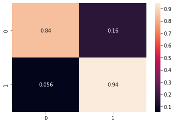

```python
#Se obtiene la prediccion sobre el conjunto de test
Test = clf.predict(s_test_class[atributos])
Real_test = list(y_test)
nor_matrix = confusion_matrix(Real_test, Test, normalize = 'true')
acur = accuracy_score(Real_test, Test)
print('El valor de accuracy del SVM sobre el conjunto de prueba es: ', acur)
sns.heatmap(nor_matrix, annot=True)
```

```python
print(classification_report(Real_test, Test))
```

```
              precision    recall  f1-score   support

           0       1.00      0.84      0.91    105230
           1       0.28      0.94      0.44      6990

    accuracy                           0.85    112220
   macro avg       0.64      0.89      0.67    112220
weighted avg       0.95      0.85      0.88    112220
```

#### Random Forest

Como segundo clasificador a trabajar se decidió el uso de Random Forest. En general, el proceso es bastante similar a lo que se hizo para SVM, pero esta vez buscando otros hiperparámetros tales como el número de árboles (50, 75, 100, 125, 150 y 200) y su profundidad máxima (2, 3, 4, 5 y 6). Luego, al igual que antes, se realizarán las predicciones.

```python
#Parametros a testear en el GridSearch
Parametros_F = {'n_estimators': [50, 75, 100, 125, 150, 200], 'max_depth': [2, 3, 4, 5, 6]}

#Clasificador Random Forest
Forest = RandomForestClassifier()

#Se buscan los parametros
clf_f = GridSearchCV(Forest, Parametros_F,cv=ps)
clf_f.fit(train_val[atributos], train_val[clases[0]])
print('El mejor clasificador tienen como cantidad de estimadores:', clf_f.best_params_['n_estimators'])
print(' ')
print('El mejor clasificador tienen como profudidad:', clf_f.best_params_['max_depth'])
```

```
El mejor clasificador tienen como cantidad de estimadores: 150

El mejor clasificador tienen como profudidad: 6
```

A continuación se realizan las predicciones en el conjunto de validación, se imprime el "accuracy" y se grafica la matriz de confusión como un mapa de calor.

```
El valor de accuracy del Random Forest sobre el conjunto de validacion es: 0.8948398825339113
```

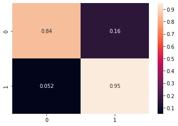

```python
#Se obtiene la prediccion sobre el conjunto de validacion
Val_f = clf_f.predict(s_Vali_class[atributos])
nor_matrix_f = confusion_matrix(Real, Val_f, normalize='true')
acur_f = accuracy_score(Real, Val_f)
print('El valor de accuracy del Random Forest sobre el conjunto de validacion es:', acur_f)
sns.heatmap(nor_matrix_f, annot=True)
```

Al igual que antes, se realizan predicciones pero esta vez sobre el conjunto de prueba, imprimiendo el accuracy y la matriz de confusión.

```
El valor de accuracy del Random Forest sobre el conjunto de prueba es:  0.8489752272322224
```

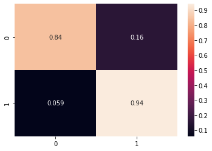

```python
#Se obtiene la prediccion sobre el conjunto de test
Test_f = clf_f.predict(s_test_class[atributos])
nor_matrix_f = confusion_matrix(Real_test, Test_f, normalize = 'true')
acur_f = accuracy_score(Real_test, Test_f)
print('El valor de accuracy del Random Forest sobre el conjunto de prueba es: ', acur_f)
sns.heatmap(nor_matrix_f, annot=True)
```

```python
print(classification_report(Real_test, Test_f))
```

```
              precision    recall  f1-score   support

           0       1.00      0.84      0.91    105230
           1       0.28      0.94      0.44      6990

    accuracy                           0.85    112220
   macro avg       0.64      0.89      0.67    112220
weighted avg       0.95      0.85      0.88    112220
```

#### KNN

```python
#Parametros a testear en el GridSearch
Parametros_KNN = {'n_neighbors': [3, 5, 7, 9, 11], 'metric': ['cosine', 'minkowski', 'manhattan', 'chebyshev']}

#Clasificador KNN
knn = KNeighborsClassifier()

#Se buscan los parametros
clf_KNN = GridSearchCV(knn, Parametros_KNN, cv=ps)
clf_KNN.fit(train_val[atributos], train_val[clases[0]])
print('El mejor clasificador tiene como cantidad de vecinos:', clf_KNN.best_params_['n_neighbors'])
print('')
print('El mejor clasificador tiene como metrica de distancia:', clf_KNN.best_params_['metric'])
```

```
El mejor clasificador tiene como cantidad de vecinos: 9

El mejor clasificador tiene como metrica de distancia: manhattan
```

```
El valor de accuracy del KNN sobre el conjunto de validacion es: 0.9046287232554887
```

[figure not shown]

```python
#Se obtiene la prediccion sobre el conjunto de validacion
Val_KNN = clf_KNN.predict(s_Vali_class[atributos])
nor_matrix_KNN = confusion_matrix(Real, Val_KNN, normalize='true')
acur_KNN = accuracy_score(Real, Val_KNN)
print('El valor de accuracy del KNN sobre el conjunto de validacion es:', acur_KNN)
sns.heatmap(nor_matrix_f, annot=True)
```

Luego, se realizan predicciones en el conjunto de prueba, imprimiendo el accuracy y su matriz de confusión.

```
El valor de accuracy del KNN sobre el conjunto de prueba es:  0.8518624131170914
```

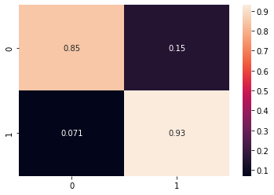

```python
#Se obtiene la prediccion sobre el conjunto de test
Test_KNN = clf_KNN.predict(s_test_class[atributos])
nor_matrix_KNN = confusion_matrix(Real_test, Test_KNN, normalize = 'true')
acur_KNN = accuracy_score(Real_test, Test_KNN)
print('El valor de accuracy del KNN sobre el conjunto de prueba es: ', acur_KNN)
sns.heatmap(nor_matrix_KNN, annot=True)
```

```python
print(classification_report(Real_test, Test_KNN))
```

```
              precision    recall  f1-score   support

           0       0.99      0.85      0.91    105230
           1       0.29      0.93      0.44      6990

    accuracy                           0.85    112220
   macro avg       0.64      0.89      0.68    112220
weighted avg       0.95      0.85      0.89    112220
```

#### Discusión de los resultados

Una observación importante es que los resultados obtenidos son prácticamente iguales entre algoritmos, puede influenciar el hecho de que cada algoritmo tiene los hiper-parámetros óptimos.

El reporte de los algoritmos entrega algo razonable dado el desbalance entre la cantidad de pacientes vivos/muertos, se evidencia que para los pacientes vivos, los puntajes de precision y recall son muy elevados, por lo que los algoritmos funcionan bien para esta clase.

Específicamente tener un precision muy cercano a 1 dice que si el algoritmo determina que un paciente vive, es muy probable que efectivamente viva.

En la clase de pacientes muertos, la baja precisión se traduce en que los algoritmos entregan una cantidad elevada de falsos positivos (FP), sin embargo, el recall $\geq $0.93 en todos los algoritmos da una información muy valiosa, la mayoría de los pacientes muertos (93%) está considerada correctamente por los clasificadores en base a las características del paciente.

### Metodología 2

Para este trabajo se propone el método de K-means, esto pues su implementación es sencilla y su tiempo de ejecución es mejor que otros algoritmos. Por otro lado, gracias a los centroides que se obtienen de K-means, los clusters se pueden interpretar más facilmente con tal de responder la pregunta ya planteada.

Luego, se usarán dos algoritmos con tal de buscar la cantidad de clusters necesarios para el algoritmo. Para ello se trabaja con el tradicional método del codo y el score de silueta.

Por último, se usa PCA para visualizar los datos y la matriz de distancias con el objetivo de validar los clusters obtenidos. Esto último se realiza con el 1% de los datos (escogidos al azar) pues considerarlos todos requiere de una capacidad computacional demasiado grande.

```python
import sklearn.preprocessing
from sklearn.cluster import KMeans
from sklearn.metrics import silhouette_score
from sklearn.decomposition import PCA
from sklearn.model_selection import train_test_split
from sklearn.metrics.pairwise import euclidean_distances
```

Luego de haber importado las librerías necesarias, se definen los atributos que estarán presentes en la formación de clusters. Por otro lado, se sabe que para las técnicas de clusterización es mejor escalar los datos por lo que se hace usando StandardScaler de sklearn.

```python
atributos=['sex', 'patient_type', 'intubed', 'pneumonia', 'age', 'pregnancy',
           'diabetes', 'copd', 'asthma', 'inmsupr', 'hypertension', 'other_disease', 'cardiovascular','obesity',
           'renal_chronic', 'tobacco', 'contact_other_covid', 'covid_res', 'icu']
X_cluster=df[atributos]

#Creamos el StandardScaler
scaler = sklearn.preprocessing.StandardScaler()

#Entrenamos el scaler en el conjunto
scaler.fit(X_cluster)

#Aplicamos el scaler al conjunto
X_cluster = scaler.transform(X_cluster)
X_cluster = pd.DataFrame(X_cluster,columns=atributos).copy(deep=True)
```

A continuación, se puede observar la base de datos ya escalada que se utiliza en el trabajo con los atributos antes seleccionados.

```python
X_cluster
```

|  | sex | patient_type | intubed | pneumonia | age | pregnancy | diabetes | copd | asthma | inmsupr | hypertension | other_disease | cardiovascular | obesity | renal_chronic | tobacco | contact_other_covid | covid_res | icu |
| --- | --- | --- | --- | --- | --- | --- | --- | --- | --- | --- | --- | --- | --- | --- | --- | --- | --- | --- | --- |
| 0 | 0.985136 | -0.521656 | 0.131922 | 0.427474 | -0.936743 | 0.085235 | 0.378026 | 0.127893 | 0.181551 | 0.126737 | 0.441981 | 0.176445 | 0.151712 | 0.441142 | 0.142279 | 0.304711 | -0.656508 | -1.107474 | 0.133501 |
| 1 | 0.985136 | -0.521656 | 0.131922 | 0.427474 | -1.117025 | 0.085235 | 0.378026 | 0.127893 | 0.181551 | 0.126737 | 0.441981 | 0.176445 | 0.151712 | 0.441142 | 0.142279 | 0.304711 | 1.494458 | -1.107474 | 0.133501 |
| 2 | -1.015088 | 1.916973 | 0.131922 | 0.427474 | 0.685791 | 0.085235 | 0.378026 | 0.127893 | 0.181551 | 0.126737 | 0.441981 | 0.176445 | 0.151712 | -2.266841 | 0.142279 | 0.304711 | 1.494458 | -1.107474 | 0.133501 |
| 3 | 0.985136 | 1.916973 | 0.131922 | -2.339325 | -0.756462 | 0.085235 | 0.378026 | 0.127893 | 0.181551 | 0.126737 | 0.441981 | 0.176445 | 0.151712 | 0.441142 | 0.142279 | 0.304711 | 1.494458 | -1.107474 | 0.133501 |
| 4 | -1.015088 | 1.916973 | 0.131922 | 0.427474 | 1.046355 | 0.085235 | -2.645320 | 0.127893 | 0.181551 | 0.126737 | -2.262540 | 0.176445 | -6.591416 | 0.441142 | 0.142279 | 0.304711 | 1.494458 | -1.107474 | 0.133501 |
| ... | ... | ... | ... | ... | ... | ... | ... | ... | ... | ... | ... | ... | ... | ... | ... | ... | ... | ... | ... |
| 561091 | 0.985136 | -0.521656 | 0.131922 | 0.427474 | 0.926167 | 0.085235 | -2.645320 | 0.127893 | 0.181551 | 0.126737 | 0.441981 | 0.176445 | 0.151712 | 0.441142 | 0.142279 | 0.304711 | -0.656508 | 1.930759 | 0.133501 |
| 561092 | -1.015088 | -0.521656 | 0.131922 | 0.427474 | 0.325228 | 0.085235 | 0.378026 | 0.127893 | 0.181551 | 0.126737 | 0.441981 | 0.176445 | 0.151712 | 0.441142 | 0.142279 | 0.304711 | -0.656508 | 1.930759 | 0.133501 |
| 561093 | -1.015088 | 1.916973 | 0.131922 | -2.339325 | 0.385322 | 0.085235 | 0.378026 | 0.127893 | 0.181551 | 0.126737 | 0.441981 | 0.176445 | 0.151712 | -2.266841 | 0.142279 | 0.304711 | 1.494458 | 1.930759 | 0.133501 |
| 561094 | -1.015088 | -0.521656 | 0.131922 | -2.339325 | 0.024759 | 0.085235 | 0.378026 | 0.127893 | 0.181551 | 0.126737 | 0.441981 | 0.176445 | 0.151712 | 0.441142 | 0.142279 | 0.304711 | -0.656508 | 1.930759 | 0.133501 |
| 561095 | 0.985136 | -0.521656 | 0.131922 | -2.339325 | 1.346824 | 0.085235 | -2.645320 | 0.127893 | 0.181551 | 0.126737 | -2.262540 | 0.176445 | 0.151712 | -2.266841 | 0.142279 | 0.304711 | -0.656508 | 1.930759 | 0.133501 |

561096 rows × 19 columns

Después del procesamiento de datos, se utiliza el método del codo y el score de silueta con el objetivo de comparar sus resultados y determinar una cantiad fija de clusters para K-means.

Ahora, se utiliza el método del codo utilizando la suma de errores cuadrados (SSE) entre 1 y 15 posibles clusters.

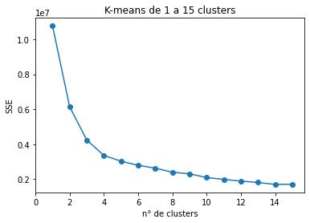

```python
sse = []

clusters = list(range(1, 16))
for k in clusters:
    kmeans = KMeans(n_clusters=k).fit(X_cluster)
    sse.append(kmeans.inertia_)

plt.plot(clusters, sse, marker="o")
plt.title("K-means de " + str(clusters[0]) + " a " + str(clusters[-1]) + " clusters")
plt.xticks(np.arange(min(clusters)-1, max(clusters)+1, 2.0))
plt.xlabel("n° de clusters")
plt.ylabel("SSE")
plt.show()
```

Dado este gráfico, se puede observar que alrededor de 4 clusters podrían ser "óptimos" para el algoritmo K-means, sin embargo, se quiere comparar este resultado con otro método.

Luego, se propone el segundo método para determinar el número de clusters. Este considera el score de silueta entre 2 y 6 clusters. Este rango de clusters se determinó dado el tiempo que demoraba en ejecutar este algoritmo.

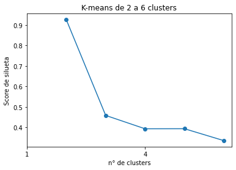

```python
silueta = []

clusters = list(range(2, 7))
for k in clusters:
    kmeans = KMeans(n_clusters=k).fit(X_cluster)
    score = silhouette_score(X_cluster, kmeans.labels_, metric='euclidean')
    silueta.append(score)

plt.plot(clusters, silueta, marker="o")
plt.title("K-means de " + str(clusters[0]) + " a " + str(clusters[-1]) + " clusters")
plt.xticks(np.arange(min(clusters)-1, max(clusters)+1, 3.0))
plt.xlabel("n° de clusters")
plt.ylabel("Score de silueta")
plt.show()
```

Considerando 2 clusters, se obtiene un puntaje de silueta cercano a 0.9, por lo que la separación entre clusters es extremadamente buena. Se decide considerar 2 clusters, por este alto coeficiente de silueta, pese a que en el método del codo no es el número óptimo.

Se validará la clusterización observando la matriz de distancias, primero se reduce el tamaño del dataset a un 1% para evitar problemas de capacidad computacional.

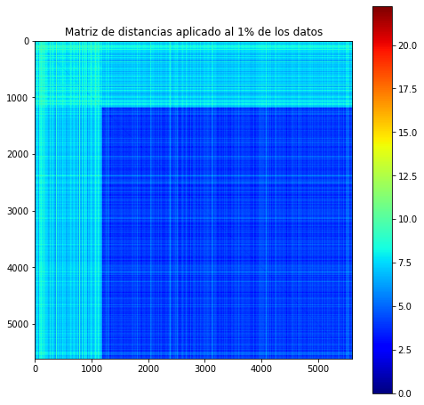

```
Centroides de los clusters:
```

|  | Cluster | sex | patient_type | intubed | pneumonia | age | pregnancy | diabetes | copd | asthma | inmsupr | hypertension | other_disease | cardiovascular | obesity | renal_chronic | tobacco | contact_other_covid | covid_res | icu |
| --- | --- | --- | --- | --- | --- | --- | --- | --- | --- | --- | --- | --- | --- | --- | --- | --- | --- | --- | --- | --- |
| 0 | 0 | 0.139733 | 1.572721 | -0.448281 | -1.396789 | 0.923932 | 0.065257 | -0.851247 | -0.456536 | 0.056504 | -0.259547 | -0.806260 | -0.194051 | -0.292889 | -0.176910 | -0.560855 | -0.056061 | 0.431075 | -0.303613 | -0.375632 |
| 1 | 1 | -0.020624 | -0.420299 | 0.130180 | 0.368100 | -0.224956 | -0.008194 | 0.220951 | 0.104557 | 0.000336 | 0.076030 | 0.175622 | 0.049718 | 0.087739 | 0.041704 | 0.129320 | -0.009624 | -0.122071 | 0.095260 | 0.131779 |

```python
X_validation, otro = train_test_split(X_cluster, test_size=0.99, random_state=42, shuffle=True)
kmeans = KMeans(n_clusters=2).fit(X_validation)
datos= X_validation.to_numpy()

plt.figure(figsize=(8, 8))

labels=kmeans.labels_

# primero ordenamos los datos en base al cluster que pertencen
indices = np.argsort(labels)
sorted_features = datos[indices]

# calculamos las distancias entre todos los puntos
dist = euclidean_distances(sorted_features, sorted_features)

plt.imshow(dist, cmap="jet")
plt.colorbar()
plt.title("Matriz de distancias aplicado al 1% de los datos")
plt.show()
print("\n")
print("Centroides de los clusters:")
centroids  = kmeans.cluster_centers_
CLUST=pd.DataFrame()
CLUST["Cluster"]=[0,1]

for i in range(len(atributos)):
  CLUST[atributos[i]]=[centroids[0][i],centroids[1][i]]

CLUST
```

En este proceso de validación se identifica que existe un cluster muy bien separado que abarca una gran cantidad de datos, los cuales se interpretan (observando los centroides) como los pacientes ambulatorios.

Con tal de visualizar el resultado de K-means, al poseer más de dos atributos en el dataframe, se requiere una reducción de dimensionalidad, es por esto que se piensa en PCA y t-SNE, sin embargo, dada la cantidad de datos que se posee ($\sim$ 500.000) se descarta t-SNE dado el gran tiempo de ejecución que posee.

```python
pca = PCA(n_components=3, svd_solver='full')

X_pca = pca.fit_transform(X_cluster)
X_pca = pd.DataFrame(X_pca,columns=["pc1","pc2","pc3"])
```

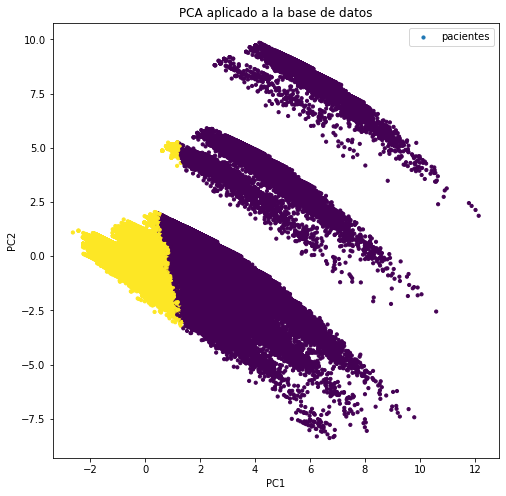

```
Atributos considerados
['sex', 'patient_type', 'intubed', 'pneumonia', 'age', 'pregnancy', 'diabetes', 'copd', 'asthma', 'inmsupr', 'hypertension', 'other_disease', 'cardiovascular', 'obesity', 'renal_chronic', 'tobacco', 'contact_other_covid', 'covid_res', 'icu']
Loadings de PC1:
[ 0.06967261  0.44490225 -0.247488   -0.41264524  0.35746047  0.03196489
 -0.32621511 -0.16088369  0.00263473 -0.10167703 -0.33351861 -0.0941468
 -0.16386755 -0.12401177 -0.18478506 -0.03195458  0.15353937 -0.13417054
 -0.23487038]
Loadings de PC2:
[ 0.10015579  0.15179499 -0.51174005 -0.22260369 -0.21684156 -0.04449702
  0.24140302  0.1812386   0.07783212  0.08868316  0.31583426  0.10011967
  0.2015226   0.13933302  0.19262554  0.05704999 -0.15126492 -0.05471642
 -0.51518603]
Loadings de PC3:
[-0.30521946  0.09219752 -0.02055472 -0.02089013 -0.21230703 -0.29031854
  0.15957225 -0.02135013 -0.1556863  -0.46429546  0.16282164 -0.53331141
 -0.078718    0.15801373 -0.15637935  0.17099891  0.2941845   0.1300527
 -0.05607922]
% de varianza explicada
[0.14985486 0.08107067 0.06404932]
```

```python
plt.figure(figsize=(8, 8))
#plt.axis('equal')
plt.scatter(X_pca["pc1"],X_pca["pc2"],s=10,label="pacientes",c=kmeans.labels_)
#plt.axvline(x=2000,c="red",linestyle='dashed')
plt.title("PCA aplicado a la base de datos")
plt.legend()
plt.xlabel("PC1")
plt.ylabel("PC2")
plt.show()

print("\n")
print("Atributos considerados")
print(atributos)
print("Loadings de PC1:")
print(pca.components_[0])
print("Loadings de PC2:")
print(pca.components_[1])
print("Loadings de PC3:")
print(pca.components_[2])
print("% de varianza explicada")
print(pca.explained_variance_ratio_)
```

En el PCA se observa que las primeras componentes principales explican poco porcentaje de varianza, por lo que el gráfico no evidencia bien como se separan los clusters obtenidos.

A continuación se hace una interpretación de los centroides de cada clusters

```python
centroids  = kmeans.cluster_centers_
CLUST=pd.DataFrame()
CLUST["Cluster"]=[0,1]

for i in range(len(atributos)):
  CLUST[atributos[i]]=[centroids[0][i],centroids[1][i]]

CLUST
```

[output not shown]

Debido a la normalización de los datos, valores negativos en columnas binarias (por ejemplo, la columna "pneumonia") significan "sí", mientras que positivos significan "no".

Se interpretan los clusters obtenidos de la siguiente manera:

Cluster 1 (Ambulatorios): Pacientes no hospitalizados, se observa que en general tienden a no presentar las enfermedades consideradas. Por otro lado, sí destaca que son propensos a ser personas que tuvieron contacto con otra persona con covid, esta puede ser una de las razones principales por la que esta gente va al hospital.

Como futura dirección, se plantea validar los clusters calculando el error cuadrático de los clusters y comparandolo con los obtenidos con datos aleatorios.

### Metodología 3

Tal como se menciono anteriormente, para responder la pregunta ¿Existen patrones que relacionen las distintas condiciones entre los pacientes estudiados? Se estudiarán las reglas de asociación del dataset más probable con ayuda del algoritmo apriori. De esta manera se buscaran las reglas que contengan los valores más altos en las metricas Confidence y Lift, para asegurarse que son los patrones más relevantes.

```python
import datetime as dt
from mlxtend.preprocessing import TransactionEncoder
from mlxtend.frequent_patterns import apriori, association_rules
import itertools
```

En primer lugar todos los valores se transforman a binarios 0 y 1. Donde 1 significa que la persona posee la condición y 0 que no.

```python
#Se elimina la columna sex dado que no sera relevante para esta metodologia
df3= df2.drop(['sex'], axis=1)

index= df3[df3["covid_res"]==3].index
df3=df3.drop(index)


def filtra2(a):
  if a!=1:
    return 0
  else:
    return 1

for c in ['pregnancy','intubed','pneumonia','diabetes','copd','asthma','inmsupr','hypertension','other_disease','cardiovascular','obesity','renal_chronic','tobacco','icu', "contact_other_covid", "covid_res"]:
  df3[c] = df3[c].apply(filtra2)
```

```python
df3
```

|  | patient_type | intubed | pneumonia | age | pregnancy | diabetes | copd | asthma | inmsupr | hypertension | other_disease | cardiovascular | obesity | renal_chronic | tobacco | contact_other_covid | covid_res | icu | died |
| --- | --- | --- | --- | --- | --- | --- | --- | --- | --- | --- | --- | --- | --- | --- | --- | --- | --- | --- | --- |
| 0 | 1 | 0 | 0 | 27 | 0 | 0 | 0 | 0 | 0 | 0 | 0 | 0 | 0 | 0 | 0 | 0 | 1 | 0 | 0 |
| 7 | 1 | 0 | 0 | 56 | 0 | 0 | 0 | 0 | 0 | 1 | 0 | 0 | 0 | 1 | 1 | 1 | 1 | 0 | 0 |
| 13 | 1 | 0 | 0 | 34 | 0 | 0 | 0 | 0 | 0 | 0 | 0 | 0 | 0 | 0 | 0 | 1 | 1 | 0 | 0 |
| 15 | 1 | 0 | 0 | 34 | 0 | 0 | 0 | 0 | 0 | 0 | 0 | 0 | 0 | 0 | 1 | 0 | 1 | 0 | 0 |
| 16 | 1 | 0 | 0 | 49 | 0 | 1 | 0 | 0 | 0 | 0 | 0 | 0 | 0 | 0 | 0 | 1 | 1 | 0 | 0 |
| ... | ... | ... | ... | ... | ... | ... | ... | ... | ... | ... | ... | ... | ... | ... | ... | ... | ... | ... | ... |
| 499686 | 1 | 0 | 0 | 15 | 0 | 0 | 0 | 0 | 0 | 0 | 0 | 0 | 0 | 0 | 0 | 1 | 0 | 0 | 0 |
| 499687 | 1 | 0 | 1 | 77 | 0 | 0 | 0 | 0 | 0 | 0 | 1 | 0 | 0 | 0 | 1 | 0 | 0 | 0 | 0 |
| 499688 | 2 | 1 | 1 | 63 | 0 | 0 | 0 | 0 | 0 | 1 | 0 | 0 | 1 | 0 | 1 | 0 | 0 | 0 | 0 |
| 499689 | 1 | 0 | 0 | 25 | 0 | 0 | 0 | 0 | 0 | 0 | 0 | 0 | 0 | 0 | 0 | 0 | 0 | 0 | 0 |
| 499690 | 1 | 0 | 0 | 45 | 0 | 0 | 0 | 0 | 0 | 1 | 0 | 0 | 0 | 0 | 0 | 1 | 0 | 0 | 0 |

342604 rows × 19 columns

Luego en la columna de edad, se definira como 1 a una persona de avanzada edad (age >= 60) y 0 como a alguien joven (age < 60). Además en la columna patient_type se definira como 1 a un paciente que estuvo hospitalizado y 0 que no.

```python
#se cambia la columna age por 0 y 1
df3.loc[df3["age"]< 60, "age"] = 0
df3.loc[df3["age"]>= 60, "age"] = 1
```

```python
#Se cambia la columna patient_type por 0 y 1
df3.loc[df3["patient_type"]== 1, "patient_type"] = 0
df3.loc[df3["patient_type"]== 2, "patient_type"] = 1
```

```python
df3
```

|  | patient_type | intubed | pneumonia | age | pregnancy | diabetes | copd | asthma | inmsupr | hypertension | other_disease | cardiovascular | obesity | renal_chronic | tobacco | contact_other_covid | covid_res | icu | died |
| --- | --- | --- | --- | --- | --- | --- | --- | --- | --- | --- | --- | --- | --- | --- | --- | --- | --- | --- | --- |
| 0 | 0 | 0 | 0 | 0 | 0 | 0 | 0 | 0 | 0 | 0 | 0 | 0 | 0 | 0 | 0 | 0 | 1 | 0 | 0 |
| 7 | 0 | 0 | 0 | 0 | 0 | 0 | 0 | 0 | 0 | 1 | 0 | 0 | 0 | 1 | 1 | 1 | 1 | 0 | 0 |
| 13 | 0 | 0 | 0 | 0 | 0 | 0 | 0 | 0 | 0 | 0 | 0 | 0 | 0 | 0 | 0 | 1 | 1 | 0 | 0 |
| 15 | 0 | 0 | 0 | 0 | 0 | 0 | 0 | 0 | 0 | 0 | 0 | 0 | 0 | 0 | 1 | 0 | 1 | 0 | 0 |
| 16 | 0 | 0 | 0 | 0 | 0 | 1 | 0 | 0 | 0 | 0 | 0 | 0 | 0 | 0 | 0 | 1 | 1 | 0 | 0 |
| ... | ... | ... | ... | ... | ... | ... | ... | ... | ... | ... | ... | ... | ... | ... | ... | ... | ... | ... | ... |
| 499686 | 0 | 0 | 0 | 0 | 0 | 0 | 0 | 0 | 0 | 0 | 0 | 0 | 0 | 0 | 0 | 1 | 0 | 0 | 0 |
| 499687 | 0 | 0 | 1 | 1 | 0 | 0 | 0 | 0 | 0 | 0 | 1 | 0 | 0 | 0 | 1 | 0 | 0 | 0 | 0 |
| 499688 | 1 | 1 | 1 | 1 | 0 | 0 | 0 | 0 | 0 | 1 | 0 | 0 | 1 | 0 | 1 | 0 | 0 | 0 | 0 |
| 499689 | 0 | 0 | 0 | 0 | 0 | 0 | 0 | 0 | 0 | 0 | 0 | 0 | 0 | 0 | 0 | 0 | 0 | 0 | 0 |
| 499690 | 0 | 0 | 0 | 0 | 0 | 0 | 0 | 0 | 0 | 1 | 0 | 0 | 0 | 0 | 0 | 1 | 0 | 0 | 0 |

342604 rows × 19 columns

Se obtienen las reglas de asociación mas frecuentes.

```python
# Apriori
freq_items = apriori(df3, min_support = 0.005, use_colnames = True, max_len=3)
freq_items.sort_values("support", ascending = True)
```

|  | support | itemsets |
| --- | --- | --- |
| 228 | 0.005003 | (cardiovascular, hypertension, covid_res) |
| 229 | 0.005035 | (obesity, tobacco, hypertension) |
| 224 | 0.005041 | (diabetes, tobacco, covid_res) |
| 167 | 0.005064 | (diabetes, covid_res, intubed) |
| 218 | 0.005070 | (diabetes, tobacco, hypertension) |
| ... | ... | ... |
| 0 | 0.150842 | (patient_type) |
| 12 | 0.158550 | (obesity) |
| 103 | 0.214198 | (contact_other_covid, covid_res) |
| 16 | 0.402660 | (covid_res) |
| 15 | 0.569453 | (contact_other_covid) |

243 rows × 2 columns

A continuación se presentan las reglas de asociación más probables entre las obtenidas anteriomente, calculando las que obtienen un valor en Confidence mayor a 0,5.

```python
df_ar = association_rules(freq_items, metric = "confidence", min_threshold = 0.5)
df_ar
```

|  | antecedents | consequents | antecedent support | consequent support | support | confidence | lift | leverage | conviction |
| --- | --- | --- | --- | --- | --- | --- | --- | --- | --- |
| 0 | (intubed) | (patient_type) | 0.020432 | 0.150842 | 0.020432 | 1.000000 | 6.629463 | 0.017350 | inf |
| 1 | (pneumonia) | (patient_type) | 0.128344 | 0.150842 | 0.106315 | 0.828364 | 5.491609 | 0.086956 | 4.947441 |
| 2 | (patient_type) | (pneumonia) | 0.150842 | 0.128344 | 0.106315 | 0.704812 | 5.491609 | 0.086956 | 2.952890 |
| 3 | (renal_chronic) | (patient_type) | 0.014139 | 0.150842 | 0.007110 | 0.502890 | 3.333892 | 0.004978 | 1.708190 |
| 4 | (patient_type) | (covid_res) | 0.150842 | 0.402660 | 0.095186 | 0.631030 | 1.567153 | 0.034448 | 1.618939 |
| ... | ... | ... | ... | ... | ... | ... | ... | ... | ... |
| 183 | (obesity, covid_res) | (contact_other_covid) | 0.078169 | 0.569453 | 0.040685 | 0.520481 | 0.914001 | -0.003828 | 0.897872 |
| 184 | (died, obesity) | (covid_res) | 0.009895 | 0.402660 | 0.008549 | 0.864012 | 2.145759 | 0.004565 | 4.392585 |
| 185 | (tobacco, covid_res) | (contact_other_covid) | 0.031415 | 0.569453 | 0.017385 | 0.553377 | 0.971769 | -0.000505 | 0.964005 |
| 186 | (died, contact_other_covid) | (covid_res) | 0.009226 | 0.402660 | 0.008082 | 0.875989 | 2.175503 | 0.004367 | 4.816814 |
| 187 | (icu, died) | (covid_res) | 0.007925 | 0.402660 | 0.006471 | 0.816575 | 2.027950 | 0.003280 | 3.256581 |

188 rows × 9 columns

A continuación se obtienen los patrones más frecuentes en el dataset (los que ocurren más del 10% de las veces).

```python
df_ar[(df_ar.support > 0.1) ].sort_values("confidence", ascending = False)
```

|  | antecedents | consequents | antecedent support | consequent support | support | confidence | lift | leverage | conviction |
| --- | --- | --- | --- | --- | --- | --- | --- | --- | --- |
| 1 | (pneumonia) | (patient_type) | 0.128344 | 0.150842 | 0.106315 | 0.828364 | 5.491609 | 0.086956 | 4.947441 |
| 2 | (patient_type) | (pneumonia) | 0.150842 | 0.128344 | 0.106315 | 0.704812 | 5.491609 | 0.086956 | 2.952890 |
| 25 | (covid_res) | (contact_other_covid) | 0.402660 | 0.569453 | 0.214198 | 0.531957 | 0.934153 | -0.015098 | 0.919886 |

Se observa que existe una alta probabilidad de que si un paciente tiene neumonia, probablemente quede hospitalizado.

A continuación se buscaran los patrones que tengan un lift menor a 1, es decir patrones que tengan una correlación negativa.

```python
df_ar[(df_ar.lift < 1) ].sort_values("lift", ascending = True)
```

|  | antecedents | consequents | antecedent support | consequent support | support | confidence | lift | leverage | conviction |
| --- | --- | --- | --- | --- | --- | --- | --- | --- | --- |
| 179 | (obesity, hypertension) | (contact_other_covid) | 0.042869 | 0.569453 | 0.021515 | 0.501872 | 0.881323 | -0.002897 | 0.864330 |
| 183 | (obesity, covid_res) | (contact_other_covid) | 0.078169 | 0.569453 | 0.040685 | 0.520481 | 0.914001 | -0.003828 | 0.897872 |
| 25 | (covid_res) | (contact_other_covid) | 0.402660 | 0.569453 | 0.214198 | 0.531957 | 0.934153 | -0.015098 | 0.919886 |
| 185 | (tobacco, covid_res) | (contact_other_covid) | 0.031415 | 0.569453 | 0.017385 | 0.553377 | 0.971769 | -0.000505 | 0.964005 |

A pesar de no encontrarse un patron con una correlación suficientemente negativa, se observa que las condiciones obesity, hipertension y tobacco son bastante idependientes de la condición contact_other_covid, lo cual es bastante logico puesto que tener presentar alguna de estas condiciones no tiene ninguna relación con tener contacto con alguien con Covid 19. Por otra parte se observa que la regla de asociación (covid_res)---->(contact_other_covid) nos muestra que presentar un resultado positivo en el test de covid 19 ocurre independientemente de haber estado en contacto con otra persona con esta enfermedad.

A contiuación se presentaran los patrones mas correlacionados positivamente (lift>10).

```python
df_ar[(df_ar.lift > 10) ].sort_values("lift", ascending = True)
```

|  | antecedents | consequents | antecedent support | consequent support | support | confidence | lift | leverage | conviction |
| --- | --- | --- | --- | --- | --- | --- | --- | --- | --- |
| 125 | (icu, intubed) | (died) | 0.010540 | 0.038035 | 0.006141 | 0.582664 | 15.319089 | 0.005740 | 2.305013 |
| 11 | (intubed) | (died) | 0.020432 | 0.038035 | 0.012253 | 0.599714 | 15.767363 | 0.011476 | 2.403196 |
| 45 | (patient_type, intubed) | (died) | 0.020432 | 0.038035 | 0.012253 | 0.599714 | 15.767363 | 0.011476 | 2.403196 |
| 112 | (pneumonia, intubed) | (died) | 0.018969 | 0.038035 | 0.011900 | 0.627327 | 16.493349 | 0.011179 | 2.581259 |
| 114 | (intubed) | (pneumonia, died) | 0.020432 | 0.033578 | 0.011900 | 0.582429 | 17.345476 | 0.011214 | 2.314387 |
| 46 | (intubed) | (died, patient_type) | 0.020432 | 0.033666 | 0.012253 | 0.599714 | 17.813812 | 0.011565 | 2.414111 |
| 116 | (intubed, age) | (died) | 0.008584 | 0.038035 | 0.005835 | 0.679701 | 17.870325 | 0.005508 | 3.003332 |
| 123 | (covid_res, intubed) | (died) | 0.014483 | 0.038035 | 0.009845 | 0.679766 | 17.872046 | 0.009294 | 3.003946 |
| 126 | (died, intubed) | (icu) | 0.012253 | 0.019626 | 0.006141 | 0.501191 | 25.536891 | 0.005901 | 1.965430 |
| 121 | (covid_res, intubed) | (icu) | 0.014483 | 0.019626 | 0.007446 | 0.514107 | 26.195001 | 0.007162 | 2.017675 |
| 9 | (icu) | (intubed) | 0.019626 | 0.020432 | 0.010540 | 0.537032 | 26.284164 | 0.010139 | 2.115842 |
| 43 | (intubed) | (icu, patient_type) | 0.020432 | 0.019626 | 0.010540 | 0.515857 | 26.284164 | 0.010139 | 2.024968 |
| 42 | (icu) | (patient_type, intubed) | 0.019626 | 0.020432 | 0.010540 | 0.537032 | 26.284164 | 0.010139 | 2.115842 |
| 41 | (patient_type, intubed) | (icu) | 0.020432 | 0.019626 | 0.010540 | 0.515857 | 26.284164 | 0.010139 | 2.024968 |
| 40 | (icu, patient_type) | (intubed) | 0.019626 | 0.020432 | 0.010540 | 0.537032 | 26.284164 | 0.010139 | 2.115842 |
| 10 | (intubed) | (icu) | 0.020432 | 0.019626 | 0.010540 | 0.515857 | 26.284164 | 0.010139 | 2.024968 |
| 111 | (icu) | (pneumonia, intubed) | 0.019626 | 0.018969 | 0.009834 | 0.501041 | 26.413089 | 0.009461 | 1.966155 |
| 110 | (pneumonia, intubed) | (icu) | 0.018969 | 0.019626 | 0.009834 | 0.518387 | 26.413089 | 0.009461 | 2.035607 |
| 119 | (icu, covid_res) | (intubed) | 0.012957 | 0.020432 | 0.007446 | 0.574679 | 28.126760 | 0.007181 | 2.303127 |
| 108 | (icu, pneumonia) | (intubed) | 0.016573 | 0.020432 | 0.009834 | 0.593343 | 29.040227 | 0.009495 | 2.408830 |
| 124 | (icu, died) | (intubed) | 0.007925 | 0.020432 | 0.006141 | 0.774954 | 37.928904 | 0.005979 | 4.352746 |

Teniendo en cuenta el principio apriori, se observa en general que existe una alta relación entre las caracteristicas ICU, Died, Pneumonia, Covid_res, patient_type e intubed. Se observa que es muy probable que si una persona caiga en la unidad de cuidados intensos, este intubada, lo cual es bastante logico. Por otra parte se ve que si una persona esta intubada tiene una alta probabilidad de fallecer tal como muestra la regla 11 de la tabla anterior. Además si es de avanzada edad y esta intubada, tiene una mayor probabilidad de fallecer, lo mismo aplica si la persona tiene neumonia y esta intubada.

Observando la regla de asociación más correlacionada, la cual es (icu, died)--->(intubed) nos muestra que si una persona estuvo dentro de los cuidados intensivos y fallecio, muy probablemente estuvo intubada.

A continuación se estudiaran los patrones existentes en el conjunto de pacientes fallecidos.

```python
#se eliminan las filas de pacientes vivos y luego la columna Died
index= df3[df3["died"]==0].index
data_died=df3.drop(index)
data_died = data_died.drop(['died'], axis=1)
data_died
```

|  | patient_type | intubed | pneumonia | age | pregnancy | diabetes | copd | asthma | inmsupr | hypertension | other_disease | cardiovascular | obesity | renal_chronic | tobacco | contact_other_covid | covid_res | icu |
| --- | --- | --- | --- | --- | --- | --- | --- | --- | --- | --- | --- | --- | --- | --- | --- | --- | --- | --- |
| 24 | 0 | 0 | 0 | 1 | 0 | 0 | 0 | 0 | 0 | 1 | 0 | 0 | 0 | 0 | 0 | 1 | 1 | 0 |
| 50 | 1 | 1 | 1 | 0 | 0 | 0 | 0 | 0 | 0 | 0 | 0 | 0 | 1 | 0 | 1 | 0 | 1 | 0 |
| 83 | 0 | 0 | 1 | 1 | 0 | 1 | 0 | 0 | 0 | 0 | 0 | 0 | 0 | 0 | 0 | 1 | 1 | 0 |
| 291 | 0 | 0 | 1 | 1 | 0 | 1 | 0 | 0 | 0 | 0 | 0 | 0 | 0 | 0 | 0 | 0 | 1 | 0 |
| 308 | 1 | 0 | 1 | 1 | 0 | 0 | 0 | 0 | 0 | 1 | 0 | 0 | 1 | 0 | 0 | 1 | 1 | 1 |
| ... | ... | ... | ... | ... | ... | ... | ... | ... | ... | ... | ... | ... | ... | ... | ... | ... | ... | ... |
| 499255 | 1 | 1 | 0 | 0 | 0 | 0 | 1 | 0 | 0 | 0 | 0 | 0 | 0 | 0 | 0 | 0 | 0 | 0 |
| 499418 | 1 | 0 | 1 | 1 | 0 | 1 | 0 | 0 | 0 | 1 | 0 | 1 | 0 | 0 | 0 | 0 | 0 | 0 |
| 499520 | 1 | 1 | 1 | 1 | 0 | 0 | 0 | 0 | 0 | 0 | 0 | 0 | 0 | 0 | 0 | 0 | 0 | 1 |
| 499582 | 1 | 0 | 1 | 0 | 0 | 0 | 0 | 0 | 0 | 1 | 0 | 0 | 0 | 0 | 0 | 0 | 0 | 0 |
| 499613 | 1 | 1 | 0 | 0 | 0 | 0 | 0 | 0 | 0 | 0 | 1 | 0 | 0 | 0 | 1 | 0 | 0 | 0 |

13031 rows × 18 columns

Se obtienen las reglas de asociación más frecuentes.

```python
# Apriori
freq_items2 = apriori(data_died, min_support = 0.005, use_colnames = True, max_len=3)
freq_items.sort_values("support", ascending = True)
```

|  | support | itemsets |
| --- | --- | --- |
| 228 | 0.005003 | (cardiovascular, hypertension, covid_res) |
| 229 | 0.005035 | (obesity, tobacco, hypertension) |
| 224 | 0.005041 | (diabetes, tobacco, covid_res) |
| 167 | 0.005064 | (diabetes, covid_res, intubed) |
| 218 | 0.005070 | (diabetes, tobacco, hypertension) |
| ... | ... | ... |
| 0 | 0.150842 | (patient_type) |
| 12 | 0.158550 | (obesity) |
| 103 | 0.214198 | (contact_other_covid, covid_res) |
| 16 | 0.402660 | (covid_res) |
| 15 | 0.569453 | (contact_other_covid) |

243 rows × 2 columns

A continuación se presentan las reglas de asociación más probables entre las obtenidas anteriomente, calculando las que obtienen un valor en Confidence mayor a 0,5.

```python
df_ar = association_rules(freq_items2, metric = "confidence", min_threshold = 0.5)
df_ar
```

|  | antecedents | consequents | antecedent support | consequent support | support | confidence | lift | leverage | conviction |
| --- | --- | --- | --- | --- | --- | --- | --- | --- | --- |
| 0 | (intubed) | (patient_type) | 0.322155 | 0.885120 | 0.322155 | 1.000000 | 1.129790 | 0.037009 | inf |
| 1 | (pneumonia) | (patient_type) | 0.882818 | 0.885120 | 0.805771 | 0.912726 | 1.031189 | 0.024371 | 1.316313 |
| 2 | (patient_type) | (pneumonia) | 0.885120 | 0.882818 | 0.805771 | 0.910352 | 1.031189 | 0.024371 | 1.307136 |
| 3 | (age) | (patient_type) | 0.522600 | 0.885120 | 0.461899 | 0.883847 | 0.998562 | -0.000665 | 0.989042 |
| 4 | (patient_type) | (age) | 0.885120 | 0.522600 | 0.461899 | 0.521848 | 0.998562 | -0.000665 | 0.998428 |
| ... | ... | ... | ... | ... | ... | ... | ... | ... | ... |
| 598 | (renal_chronic, contact_other_covid) | (covid_res) | 0.011971 | 0.813445 | 0.009055 | 0.756410 | 0.929885 | -0.000683 | 0.765858 |
| 599 | (icu, renal_chronic) | (covid_res) | 0.013276 | 0.813445 | 0.008595 | 0.647399 | 0.795873 | -0.002204 | 0.529083 |
| 600 | (tobacco, contact_other_covid) | (covid_res) | 0.022638 | 0.813445 | 0.018878 | 0.833898 | 1.025144 | 0.000463 | 1.123138 |
| 601 | (icu, tobacco) | (covid_res) | 0.018955 | 0.813445 | 0.014350 | 0.757085 | 0.930715 | -0.001068 | 0.767985 |
| 602 | (icu, contact_other_covid) | (covid_res) | 0.047349 | 0.813445 | 0.040135 | 0.847650 | 1.042050 | 0.001620 | 1.224516 |

603 rows × 9 columns

A continuación se presentan los patrones que ocurren con mayor frecuencia (que ocurran más del 10% de las veces).

```python
df_ar[(df_ar.support > 0.1) & (df_ar.lift > 2) ].sort_values("lift", ascending = True)
```

|  | antecedents | consequents | antecedent support | consequent support | support | confidence | lift | leverage | conviction |
| --- | --- | --- | --- | --- | --- | --- | --- | --- | --- |
| 22 | (intubed) | (icu) | 0.322155 | 0.208349 | 0.161461 | 0.501191 | 2.405532 | 0.094340 | 1.587082 |
| 87 | (patient_type, intubed) | (icu) | 0.322155 | 0.208349 | 0.161461 | 0.501191 | 2.405532 | 0.094340 | 1.587082 |
| 89 | (intubed) | (icu, patient_type) | 0.322155 | 0.208349 | 0.161461 | 0.501191 | 2.405532 | 0.094340 | 1.587082 |
| 21 | (icu) | (intubed) | 0.208349 | 0.322155 | 0.161461 | 0.774954 | 2.405532 | 0.094340 | 3.012029 |
| 86 | (icu, patient_type) | (intubed) | 0.208349 | 0.322155 | 0.161461 | 0.774954 | 2.405532 | 0.094340 | 3.012029 |
| 88 | (icu) | (patient_type, intubed) | 0.208349 | 0.322155 | 0.161461 | 0.774954 | 2.405532 | 0.094340 | 3.012029 |
| 317 | (icu, covid_res) | (intubed) | 0.170133 | 0.322155 | 0.133298 | 0.783491 | 2.432033 | 0.078488 | 3.130797 |
| 278 | (pneumonia, intubed) | (icu) | 0.312869 | 0.208349 | 0.158545 | 0.506745 | 2.432190 | 0.093359 | 1.604953 |
| 279 | (icu) | (pneumonia, intubed) | 0.208349 | 0.312869 | 0.158545 | 0.760958 | 2.432190 | 0.093359 | 2.874514 |
| 276 | (icu, pneumonia) | (intubed) | 0.199754 | 0.322155 | 0.158545 | 0.793700 | 2.463721 | 0.094193 | 3.285719 |
| 320 | (icu) | (covid_res, intubed) | 0.208349 | 0.258844 | 0.133298 | 0.639779 | 2.471675 | 0.079367 | 2.057503 |
| 319 | (covid_res, intubed) | (icu) | 0.258844 | 0.208349 | 0.133298 | 0.514972 | 2.471675 | 0.079367 | 1.632175 |

Se observa que los patrones más correlacionados positivamente relacionan las condiciones Pneumonia, intubed y ICU. Por lo cual es muy probable que los pacientes contengan al menos 2 de estas condiciones si es que presentan al menos alguna de ellas.

A continuación se presentan las reglas de asociación más correlacionadas negativamente (lift<1).

```python
df_ar[(df_ar.lift <1 ) ].sort_values("lift", ascending = True)
```

|  | antecedents | consequents | antecedent support | consequent support | support | confidence | lift | leverage | conviction |
| --- | --- | --- | --- | --- | --- | --- | --- | --- | --- |
| 560 | (tobacco, copd) | (covid_res) | 0.011741 | 0.813445 | 0.006983 | 0.594771 | 0.731176 | -2.567498e-03 | 0.460370 |
| 225 | (other_disease, patient_type) | (covid_res) | 0.030696 | 0.813445 | 0.018341 | 0.597500 | 0.734530 | -6.628651e-03 | 0.463491 |
| 60 | (other_disease) | (covid_res) | 0.033919 | 0.813445 | 0.020490 | 0.604072 | 0.742610 | -7.101729e-03 | 0.471185 |
| 412 | (other_disease) | (pneumonia, covid_res) | 0.033919 | 0.726498 | 0.018418 | 0.542986 | 0.747402 | -6.224562e-03 | 0.598454 |
| 204 | (inmsupr, patient_type) | (covid_res) | 0.027857 | 0.813445 | 0.017036 | 0.611570 | 0.751828 | -5.623550e-03 | 0.480280 |
| ... | ... | ... | ... | ... | ... | ... | ... | ... | ... |
| 33 | (renal_chronic) | (pneumonia) | 0.060855 | 0.882818 | 0.053641 | 0.881463 | 0.998465 | -8.246423e-05 | 0.988568 |
| 4 | (patient_type) | (age) | 0.885120 | 0.522600 | 0.461899 | 0.521848 | 0.998562 | -6.651730e-04 | 0.998428 |
| 3 | (age) | (patient_type) | 0.522600 | 0.885120 | 0.461899 | 0.883847 | 0.998562 | -6.651730e-04 | 0.989042 |
| 108 | (hypertension) | (pneumonia, patient_type) | 0.391298 | 0.805771 | 0.315172 | 0.805452 | 0.999604 | -1.247475e-04 | 0.998361 |
| 245 | (renal_chronic, covid_res) | (patient_type) | 0.042744 | 0.885120 | 0.037833 | 0.885099 | 0.999976 | -9.128012e-07 | 0.999814 |

159 rows × 9 columns

Se observa que condiciones como tobacco, copd, other_disease y patient_type estan correlacionados negativamente con Covid_res, es decir que presentar las condiciones anteriores provocas que sea menos que el paciente mostrara un resultado positivo al test de covid 19. Sin embargo dado que los valores de Lift son cercanos a 1 y las afirmaciones anteriores no tienen sentido alguno, se asumiran las condiciones como variables independientes.

A continuación se presentan las variables más correlacionadas positivamente (lifr>2).

```python
df_ar[(df_ar.lift > 2) ].sort_values("lift", ascending = True)
```

|  | antecedents | consequents | antecedent support | consequent support | support | confidence | lift | leverage | conviction |
| --- | --- | --- | --- | --- | --- | --- | --- | --- | --- |
| 530 | (renal_chronic, hypertension) | (diabetes) | 0.042054 | 0.372803 | 0.032001 | 0.760949 | 2.041154 | 0.016323 | 2.623693 |
| 297 | (icu, inmsupr) | (intubed) | 0.007674 | 0.322155 | 0.005065 | 0.660000 | 2.048704 | 0.002593 | 1.993662 |
| 525 | (diabetes, cardiovascular) | (hypertension) | 0.028854 | 0.391298 | 0.023176 | 0.803191 | 2.052635 | 0.011885 | 3.092866 |
| 307 | (icu, cardiovascular) | (intubed) | 0.012125 | 0.322155 | 0.008518 | 0.702532 | 2.180727 | 0.004612 | 2.278713 |
| 294 | (icu, copd) | (intubed) | 0.009209 | 0.322155 | 0.006523 | 0.708333 | 2.198736 | 0.003556 | 2.324040 |
| 312 | (icu, renal_chronic) | (intubed) | 0.013276 | 0.322155 | 0.009746 | 0.734104 | 2.278730 | 0.005469 | 2.549287 |
| 287 | (icu, age) | (intubed) | 0.102525 | 0.322155 | 0.075896 | 0.740269 | 2.297868 | 0.042867 | 2.609801 |
| 302 | (icu, hypertension) | (intubed) | 0.077738 | 0.322155 | 0.057709 | 0.742349 | 2.304325 | 0.032665 | 2.630870 |
| 292 | (diabetes, icu) | (intubed) | 0.075896 | 0.322155 | 0.057939 | 0.763397 | 2.369660 | 0.033489 | 2.864910 |
| 316 | (icu, contact_other_covid) | (intubed) | 0.047349 | 0.322155 | 0.036452 | 0.769854 | 2.389702 | 0.021198 | 2.945285 |
| 22 | (intubed) | (icu) | 0.322155 | 0.208349 | 0.161461 | 0.501191 | 2.405532 | 0.094340 | 1.587082 |
| 87 | (patient_type, intubed) | (icu) | 0.322155 | 0.208349 | 0.161461 | 0.501191 | 2.405532 | 0.094340 | 1.587082 |
| 89 | (intubed) | (icu, patient_type) | 0.322155 | 0.208349 | 0.161461 | 0.501191 | 2.405532 | 0.094340 | 1.587082 |
| 21 | (icu) | (intubed) | 0.208349 | 0.322155 | 0.161461 | 0.774954 | 2.405532 | 0.094340 | 3.012029 |
| 88 | (icu) | (patient_type, intubed) | 0.208349 | 0.322155 | 0.161461 | 0.774954 | 2.405532 | 0.094340 | 3.012029 |
| 86 | (icu, patient_type) | (intubed) | 0.208349 | 0.322155 | 0.161461 | 0.774954 | 2.405532 | 0.094340 | 3.012029 |
| 531 | (renal_chronic) | (diabetes, hypertension) | 0.060855 | 0.217328 | 0.032001 | 0.525851 | 2.419621 | 0.018775 | 1.650689 |
| 317 | (icu, covid_res) | (intubed) | 0.170133 | 0.322155 | 0.133298 | 0.783491 | 2.432033 | 0.078488 | 3.130797 |
| 279 | (icu) | (pneumonia, intubed) | 0.208349 | 0.312869 | 0.158545 | 0.760958 | 2.432190 | 0.093359 | 2.874514 |
| 278 | (pneumonia, intubed) | (icu) | 0.312869 | 0.208349 | 0.158545 | 0.506745 | 2.432190 | 0.093359 | 1.604953 |
| 314 | (icu, tobacco) | (intubed) | 0.018955 | 0.322155 | 0.015041 | 0.793522 | 2.463170 | 0.008935 | 3.282897 |
| 276 | (icu, pneumonia) | (intubed) | 0.199754 | 0.322155 | 0.158545 | 0.793700 | 2.463721 | 0.094193 | 3.285719 |
| 320 | (icu) | (covid_res, intubed) | 0.208349 | 0.258844 | 0.133298 | 0.639779 | 2.471675 | 0.079367 | 2.057503 |
| 319 | (covid_res, intubed) | (icu) | 0.258844 | 0.208349 | 0.133298 | 0.514972 | 2.471675 | 0.079367 | 1.632175 |
| 309 | (icu, obesity) | (intubed) | 0.059934 | 0.322155 | 0.047809 | 0.797695 | 2.476124 | 0.028501 | 3.350614 |
| 310 | (obesity, intubed) | (icu) | 0.091628 | 0.208349 | 0.047809 | 0.521776 | 2.504330 | 0.028719 | 1.655396 |
| 304 | (icu, other_disease) | (intubed) | 0.008595 | 0.322155 | 0.006983 | 0.812500 | 2.522079 | 0.004214 | 3.615174 |
| 305 | (other_disease, intubed) | (icu) | 0.012969 | 0.208349 | 0.006983 | 0.538462 | 2.584417 | 0.004281 | 1.715243 |
| 298 | (inmsupr, intubed) | (icu) | 0.009286 | 0.208349 | 0.005065 | 0.545455 | 2.617981 | 0.003130 | 1.741631 |

Se puede observar que existe una alta probabilidad de que si el paciente caiga en cuidados intensivos y que presente alguna enfermedad u otra condición que afecte su salud, quede intubado.

# Asignación de labores

## Labores Hito 1

- Sebastián Cobaise: Matriz de correlación, tratamiento de datos y normalización.
- Bastián Garcés: Introducción y estructuración del informe.
- Arturo Lazcano: Explicación de atributos y descripción preliminar de los datos.
- Jonas Peñailillo: Introducción y edición del video.
- Eduardo Silva: Creación de histogramas y estudios de variables más correlacionadas.

## Labores Hito 2

- Bastián Garcés y Jonas Peñailillo: Implementación de la metodología, códigos del Hito 2
- Arturo Lazcano y Sebastián Cobaise: Redacción de la sección "Hito 2"
- Eduardo Silva: Mejora del Hito 1 en la sección "Hito 1"

## Labores Hito 3

- Sebastián Cobaise y Arturo Lazcano: Redacción y código de la metodología 2.
- Eduardo Silva: Redacción y código de la metodología 3.
- Bastián Garcés y Jonas Peñailillo: Incorporación de feedback en hito 2, creación del PPT y edición del video.